# Reproducible Analyses

Erin M. Buchanan

2026-04-12

- Using manuscript + supplement from https://drive.google.com/drive/u/0/folders/1_lBKpwcRFFIUcJZq8XENDovHmMNC8m5I
- Using analyses from https://drive.google.com/drive/u/0/folders/1V00hNRQofmBxloVls-Vxy1t30henrzGw
- Using pre-registration from https://docs.google.com/document/d/1nCfUY9tJLBk41vE_BU56S10rrBoRdVaMwDFo1DMZy8M/edit?tab=t.0#heading=h.fwbi14d4b65g

## Libraries

```r
library(rio)
library(dplyr)
library(psych)
library(dplyr)
library(tidyr)
library(stringr)
library(lavaan)
library(broom)
library(sirt)
library(sf)
library(rnaturalearth)
library(viridis)
library(patchwork)
library(beepr)
library(readr)
library(misty)
```

```r
library(ggplot2)
library(lme4)
library(parameters)
library(performance)
library(apaTables)

pct <- function(x) round(100 * x, 1)

largest_group <- function(vec) {
  tab <- prop.table(table(vec))
  top <- names(which.max(tab))
  p <- pct(max(tab, na.rm = TRUE))
  paste0(top, " (", p, "%)")
}

RUN_MODEL <- TRUE # change me to rerun models
```

## Robustness Analysis Notes

- This analysis includes only participants with complete data for analyses *after* the model building.
- Recoding sections were included to ensure the same structure for analyses.

# Data

```r
# load data
dt <- import("../data/processed_data/dhf_data_final.csv.zip")
```

## Sample Summary

```r
#L: variable names changed to match the new data
factorized_var_numbers<-
  c(which(names(dt)=="gender"),
    which(names(dt)=="Migration"),
    which(names(dt)=="location_childhood"),
    which(names(dt)=="location_current"),
    which(names(dt)=="ethnicity"),
    which(names(dt)=="religion"),
    which(names(dt)=="education"),
    which(names(dt)=="student"),
    which(names(dt)=="income"),
    which(names(dt)=="Country"),
    which(names(dt)=="country_res_full"),
    which(names(dt)=="Sample"),
    which(names(dt)=="datasource"))

numeric_var_numbers<-
  c(which(names(dt)=="Age"))

# refactor gender, age, education, state, race, migration
dt[,factorized_var_numbers] <- lapply(dt[,factorized_var_numbers], as.factor)
dt[,numeric_var_numbers] <- as.numeric(dt[,numeric_var_numbers])
```

```r
# recode variables to numeric
dt <- dt %>%
  mutate_at(vars(Reciprocity_1:Reciprocity_6), ~dplyr::case_when(
    . == "Does not apply to me at all\r\n1\r\n" ~ 1,
    . == "1" ~ 1,
    . == "2" ~ 2,
    . == "3" ~ 3,
    . == "4" ~ 4,
    . == "5" ~ 5,
    . == "6" ~ 6,
    . == "7" ~ 6,
    . == "Applies to me perfectly\r\n7\r\n" ~ 7,
    TRUE ~ NA_integer_
  ))

# examine data
Recprocity_first_num <- which(names(dt)=="Reciprocity_1")
Recprocity_last_num <- which(names(dt)=="Reciprocity_6")

# calculate positive and negative reciprocity
dt$Positive_Reciprocity <- rowMeans(dt[c("Reciprocity_1","Reciprocity_2","Reciprocity_3")], na.rm=TRUE)
dt$Negative_Reciprocity <- rowMeans(dt[c("Reciprocity_4","Reciprocity_5","Reciprocity_6")], na.rm=TRUE)
```

- exclude participants who are too young

```r
# exclude participants who are <18
dt1 <- subset(dt, Age >=18|is.na(Age))
```

- remove people who were not bord and raised in the country

```r
# NAs are cases where question was not shown, so include
dt2 <- subset(dt1, Migration==1|Migration==3|is.na(Migration)) #n=35901
```

- remove due to attention checks

```r
# exclude participants who failed 2 or 3 attention checks, except for ALLS countries where attention checks were not shown
dt2$attention1 <- ifelse(dt2$attention_1==2|dt2$datasource == "ALLS", 1, 0)
dt2$attention2 <- ifelse(dt2$attention_2==5|dt2$datasource == "ALLS", 1, 0)
dt2$attention3 <- ifelse(dt2$attention_3==3|dt2$datasource == "ALLS", 1, 0)
dt2$attention <- rowSums(dt2[c("attention1", "attention2", "attention3")], na.rm=T)
dt3 <- subset(dt2, attention>=2)
```

- remove due to too small sample

```r
# exclude countries with <50 participants and where country is missing
# table(dt3$country_res_full, useNA = "ifany")
dt3$country_res_full <- as.factor(dt3$country_res_full)

dt4 <- dt3 %>%
  group_by(country_res_full) %>%
  filter(!is.na(country_res_full) & n() >= 50) %>%
  ungroup() %>%
  mutate(country_res_full = droplevels(country_res_full))

#all -99 and -999 in the dataset are now assigned as missing
dt4[dt4 == -99] <- NA
dt4[dt4 == -999] <- NA
```

## Create Indices

```r
# Ensure Schwartz values are merged (if not already done in the reliability check stage)
print("Ensuring Schwartz values are merged...")
```

```
## [1] "Ensuring Schwartz values are merged..."
```

```r
for(i in 1:21) {
  col_name <- paste0("values_", i)
  col_n <- paste0("values_n_", i)
  col_m <- paste0("values_m_", i)
  col_f <- paste0("values_f_", i)

  if(all(c(col_n, col_m, col_f) %in% names(dt4))) {
    dt4 <- dt4 %>%
      mutate(!!col_name := coalesce(!!sym(col_n), !!sym(col_m), !!sym(col_f)))
  }
}

print("CREATING SCALE INDICES")
```

```
## [1] "CREATING SCALE INDICES"
```

```r
print(paste(rep("=", 50), collapse = ""))
```

```
## [1] "=================================================="
```

```r
# Function to calculate mean with at least 50% valid responses
calculate_scale_mean <- function(data, vars, min_valid_prop = 0.5) {
  # Check which variables exist
  available_vars <- vars[vars %in% names(data)]

  if(length(available_vars) == 0) {
    return(rep(NA, nrow(data)))
  }

  # Calculate means requiring at least 50% valid responses
  scale_data <- data[, available_vars, drop = FALSE]
  n_items <- ncol(scale_data)
  min_valid <- ceiling(n_items * min_valid_prop)

  # Calculate row means with minimum valid responses
  row_means <- rowMeans(scale_data, na.rm = TRUE)
  valid_count <- rowSums(!is.na(scale_data))

  # Set to NA if insufficient valid responses
  row_means[valid_count < min_valid] <- NA

  return(row_means)
}

# Create all scale indices
print("1. Creating reciprocity indices...")
```

```
## [1] "1. Creating reciprocity indices..."
```

```r
# 1. RECIPROCITY
dt4 <- dt4 %>%
  mutate(
    Positive_Reciprocity = calculate_scale_mean(., c("Reciprocity_1", "Reciprocity_2", "Reciprocity_3")),
    Negative_Reciprocity = calculate_scale_mean(., c("Reciprocity_4", "Reciprocity_5", "Reciprocity_6"))
  )

print("2. Creating violence attitude indices...")
```

```
## [1] "2. Creating violence attitude indices..."
```

```r
# 2. VIOLENCE ATTITUDES
dt4 <- dt4 %>%
  mutate(
    Penal_Code_Violence = calculate_scale_mean(., c("violence_1", "violence_2", "violence_3")),
    War_Acceptance = calculate_scale_mean(., c("violence_4", "violence_5", "violence_6")),
    Corporal_Punishment = calculate_scale_mean(., c("violence_7", "violence_8", "violence_9")),
    Intimate_Violence = calculate_scale_mean(., c("violence_10", "violence_11", "violence_12")),
    Total_Violence = calculate_scale_mean(., paste0("violence_", 1:12))
  )

print("3. Creating face concern indices...")
```

```
## [1] "3. Creating face concern indices..."
```

```r
# 3. FACE CONCERNS
dt4 <- dt4 %>%
  mutate(
    Other_Face_Concern = calculate_scale_mean(., c("conflict_face_2", "conflict_face_3", "conflict_face_4",
                                                   "conflict_face_5", "conflict_face_6", "conflict_face_7")),
    Self_Face_Concern = calculate_scale_mean(., c("conflict_face_8", "conflict_face_9", "conflict_face_10", "conflict_face_11"))
  )

print("4. Creating reactions to insult indices (excluding 3rd scenario)...")
```

```
## [1] "4. Creating reactions to insult indices (excluding 3rd scenario)..."
```

```r
# 4. REACTIONS TO PROVOCATION (excluding 3rd scenario items due to problematic alpha)
dt4 <- dt4 %>%
  mutate(
    Withdrawal = calculate_scale_mean(., c("insult1_1", "insult2_1")),
    Retaliation = calculate_scale_mean(., c("insult1_2", "insult2_2")),
    Humor = calculate_scale_mean(., c("insult1_3", "insult2_3"))
  )

print("5. Creating Schwartz higher-order values indices...")
```

```
## [1] "5. Creating Schwartz higher-order values indices..."
```

```r
# 5. SCHWARTZ HIGHER-ORDER VALUES
dt4 <- dt4 %>%
  mutate(
    Self_Transcendence = calculate_scale_mean(., paste0("values_", c(3, 8, 19, 12, 18))),
    Self_Enhancement = calculate_scale_mean(., paste0("values_", c(4, 13, 2, 17))),
    Openness_to_Change = calculate_scale_mean(., paste0("values_", c(1, 11, 6, 15, 10, 21))),
    Conservation = calculate_scale_mean(., paste0("values_", c(5, 14, 7, 16, 9, 20)))
  )

print("6. Creating moral foundations indices...")
```

```
## [1] "6. Creating moral foundations indices..."
```

```r
# 6. MORAL FOUNDATIONS
dt4 <- dt4 %>%
  mutate(
    MFQ_Care = calculate_scale_mean(., paste0("MFQ_", c(1, 7, 13, 19, 25, 31))),
    MFQ_Equality = calculate_scale_mean(., paste0("MFQ_", c(2, 8, 14, 20, 26, 32))),
    MFQ_Proportionality = calculate_scale_mean(., paste0("MFQ_", c(3, 9, 15, 21, 27, 33))),
    MFQ_Loyalty = calculate_scale_mean(., paste0("MFQ_", c(4, 10, 16, 22, 28, 34))),
    MFQ_Authority = calculate_scale_mean(., paste0("MFQ_", c(5, 11, 17, 23, 29, 35))),
    MFQ_Purity = calculate_scale_mean(., paste0("MFQ_", c(6, 12, 18, 24, 30, 36)))
  )

print("7. Creating religiosity indices...")
```

```
## [1] "7. Creating religiosity indices..."
```

```r
# 7. INTRINSIC RELIGIOSITY (raw scores)
dt4 <- dt4 %>%
  mutate(
    Intrinsic_Religiosity = calculate_scale_mean(., c("relig_intrinsic_1", "relig_intrinsic_2", "relig_intrinsic_3"))
  )

# 8. COMPOSITE RELIGIOSITY (standardized scores)
print("8. Creating composite religiosity index (standardized scores)...")
```

```
## [1] "8. Creating composite religiosity index (standardized scores)..."
```

```r
# Check if religiosity variables exist
religiosity_vars <- c("relig_attendance", "relig_private", "relig_intrinsic_1", "relig_intrinsic_2", "relig_intrinsic_3")
available_relig_vars <- religiosity_vars[religiosity_vars %in% names(dt4)]

if(length(available_relig_vars) > 0) {
  # Standardize each religiosity variable
  dt4_standardized <- dt4
  for(var in available_relig_vars) {
    dt4_standardized[[paste0(var, "_z")]] <- scale(dt4[[var]])[,1]
  }

  # Calculate composite score from standardized variables
  standardized_vars <- paste0(available_relig_vars, "_z")
  dt4$Composite_Religiosity <- calculate_scale_mean(dt4_standardized, standardized_vars)

  cat("Composite religiosity created using:", paste(available_relig_vars, collapse = ", "), "\n")
} else {
  dt4$Composite_Religiosity <- NA
  cat("Warning: Religiosity variables not found. Composite religiosity set to NA.\n")
}
```

```
## Composite religiosity created using: relig_attendance, relig_private, relig_intrinsic_1, relig_intrinsic_2, relig_intrinsic_3
```

```r
print("9. Creating subjective well-being index...")
```

```
## [1] "9. Creating subjective well-being index..."
```

```r
# 9. SUBJECTIVE WELL-BEING
dt4 <- dt4 %>%
  mutate(
    Subjective_Wellbeing = calculate_scale_mean(., c("swbls_1", "swbls_2", "swbls_3", "swbls_4", "swbls_5"))
  )

# List all created indices
created_indices <- c(
  "Positive_Reciprocity", "Negative_Reciprocity",
  "Penal_Code_Violence", "War_Acceptance", "Corporal_Punishment", "Intimate_Violence", "Total_Violence",
  "Other_Face_Concern", "Self_Face_Concern",
  "Withdrawal", "Retaliation", "Humor",
  "Self_Transcendence", "Self_Enhancement", "Openness_to_Change", "Conservation",
  "MFQ_Care", "MFQ_Equality", "MFQ_Proportionality", "MFQ_Loyalty", "MFQ_Authority", "MFQ_Purity",
  "Intrinsic_Religiosity", "Composite_Religiosity", "Subjective_Wellbeing"
)

print("\nCreated indices:")
```

```
## [1] "\nCreated indices:"
```

```r
print(created_indices)
```

```
##  [1] "Positive_Reciprocity"  "Negative_Reciprocity"  "Penal_Code_Violence"
##  [4] "War_Acceptance"        "Corporal_Punishment"   "Intimate_Violence"
##  [7] "Total_Violence"        "Other_Face_Concern"    "Self_Face_Concern"
## [10] "Withdrawal"            "Retaliation"           "Humor"
## [13] "Self_Transcendence"    "Self_Enhancement"      "Openness_to_Change"
## [16] "Conservation"          "MFQ_Care"              "MFQ_Equality"
## [19] "MFQ_Proportionality"   "MFQ_Loyalty"           "MFQ_Authority"
## [22] "MFQ_Purity"            "Intrinsic_Religiosity" "Composite_Religiosity"
## [25] "Subjective_Wellbeing"
```

## Include Clustering Variable for Later

```r
dt4$cluster <- recode_factor(dt4$country_res_full,
                             "Argentina" = "Latin America",
                             "Brazil" = "Latin America",
                             "Chile" = "Latin America",
                             "Mexico" = "Latin America",
                             "Armenia" = "Eastern Europe",
                             "Bosnia-Herzegovina" = "Eastern Europe",
                             "Bulgaria" = "Eastern Europe",
                             "Croatia" = "Eastern Europe",
                             "Czech Republic" = "Eastern Europe",
                             "Georgia" = "Eastern Europe",
                             "Greece" = "Eastern Europe",
                             "Hungary" = "Eastern Europe",
                             "Kosovo" = "Eastern Europe",
                             "North Macedonia" = "Eastern Europe",
                             "Poland" = "Eastern Europe",
                             "Russia" = "Eastern Europe",
                             "Serbia" = "Eastern Europe",
                             "Slovakia" = "Eastern Europe",
                             "Kazakhstan" = "Eastern Europe",
                             "Ukraine" = "Eastern Europe",
                             "Australia" = "Anglo-Saxon",
                             "Canada" = "Anglo-Saxon",
                             "New Zealand" = "Anglo-Saxon",
                             "Ireland" = "Anglo-Saxon",
                             "United Kingdom" = "Anglo-Saxon",
                             "United States" = "Anglo-Saxon",
                             "Austria" = "Germanic",
                             "Germany" = "Germanic",
                             "Switzerland" = "Germanic",
                             "The Netherlands" = "Germanic",
                             "Bangladesh" = "South-East Asia",
                             "India" = "South-East Asia",
                             "Indonesia" = "South-East Asia",
                             "Iran" = "South-East Asia",
                             "Malaysia" = "South-East Asia",
                             "Pakistan" = "South-East Asia",
                             "Philippines" = "South-East Asia",
                             "Thailand" = "South-East Asia",
                             "Cameroon" = "Africa",
                             "Ethiopia" = "Africa",
                             "Kenya" = "Africa",
                             "Namibia" = "Africa",
                             "Nigeria" = "Africa",
                             "South Africa" = "Africa",
                             "Ghana" = "Africa",
                             "China" = "Confucian",
                             "Japan" = "Confucian",
                             "Singapore" = "Confucian",
                             "Hong Kong" = "Confucian",
                             "Taiwan" = "Confucian",
                             "Vietnam" = "Confucian",
                             "France" = "Latin Europe",
                             "Israel" = "Latin Europe",
                             "Italy" = "Latin Europe",
                             "Portugal" = "Latin Europe",
                             "Romania" = "Latin Europe",
                             "Spain" = "Latin Europe",
                             "Kuwait" = "Middle East",
                             "Morocco" = "Middle East",
                             "Saudi Arabia" = "Middle East",
                             "Lebanon" = "Middle East",
                             "Turkey" = "Middle East",
                             "Uzbekistan" = "Middle East",
                             "United Arab Emirates" = "Middle East")

dt4[dt4 == -99] <- NA
```

## Missing Data

- for this robustness test run only on people who have these variables

```r
# variables they need
vars_needed <- c(
  # dictator
  "Dictator.comp1.1_dich", "Dictator.comp2.1_dich", "Dictator.comp1.2_dich",
  "Dictator.comp2.2_dich", "Dictator_decision",
  # ultimatum
  "Ultimatum.comp.1.1_dich", "Ultimatum.comp.2.1_dich", "Ultimatum.comp.1.2_dich",
  "Ultimatum.comp.2.2_dich", "Ultimatum.Receiver_1", "Ultimatum.Receiver_2",
  "Ultimatum.Receiver_3", "Ultimatum.Receiver_4", "Ultimatum.Receiver_5",
  "Ultimatum.Receiver_6", "Ultimatum.Receiver_7", "Ultimatum.Receiver_8",
  "Ultimatum.Receiver_9", "Ultimatum.Receiver_10", "Ultimatum.Receiver_11",
  "Ultimatum.Proposer_1", "Ultimatum.Proposer_2",
  "Ultimatum.Proposer_3", "Ultimatum.Proposer_4", "Ultimatum.Proposer_5",
  "Ultimatum.Proposer_6", "Ultimatum.Proposer_7", "Ultimatum.Proposer_8",
  "Ultimatum.Proposer_9", "Ultimatum.Proposer_10", "Ultimatum.Proposer_11",
  # dhf scores
  "dhf_endors_1", "dhf_endors_2", "dhf_endors_3", "dhf_endors_4", "dhf_endors_5",
  "dhf_endors_6", "dhf_endors_7", "dhf_endors_8", "dhf_endors_9", "dhf_endors_10",
  "dhf_endors_11", "dhf_endors_12", "dhf_endors_13", "dhf_endors_14", "dhf_endors_15",
  "dhf_endors_16", "dhf_endors_17", "dhf_endors_18", "dhf_endors_19", "dhf_endors_20",
  "dhf_endors_21", "dhf_endors_22", "dhf_endors_23", "dhf_endors_24", "dhf_endors_25",
  "dhf_endors_26", "dhf_endors_27", "dhf_endors_28", "dhf_endors_29", "dhf_endors_30",
  "dhf_norm_1", "dhf_norm_2", "dhf_norm_3", "dhf_norm_4", "dhf_norm_5",
  "dhf_norm_6", "dhf_norm_7", "dhf_norm_8", "dhf_norm_9", "dhf_norm_10",
  "dhf_norm_11", "dhf_norm_12", "dhf_norm_13", "dhf_norm_14", "dhf_norm_15",
  "dhf_norm_16", "dhf_norm_17", "dhf_norm_18", "dhf_norm_19", "dhf_norm_20",
  "dhf_norm_21", "dhf_norm_22", "dhf_norm_23", "dhf_norm_24", "dhf_norm_25",
  "dhf_norm_26", "dhf_norm_27", "dhf_norm_28", "dhf_norm_29", "dhf_norm_30",
  # other face
  "conflict_face_2", "conflict_face_3", "conflict_face_4", "conflict_face_5",
  "conflict_face_6", "conflict_face_7", "conflict_face_8", "conflict_face_9",
  "conflict_face_10", "Other_Face_Concern", "Self_Face_Concern",
  # other cultural variables
  "Openness_to_Change", "Conservation", "Self_Transcendence", "Self_Enhancement",
  # reciprocity
  "Reciprocity_1","Reciprocity_2","Reciprocity_3", "Positive_Reciprocity",
  "Reciprocity_4","Reciprocity_5","Reciprocity_6", "Negative_Reciprocity",
  # violence
  "violence_1", "violence_2", "violence_3", "violence_4", "violence_5",
  "violence_6", "violence_7", "violence_8", "violence_9", "violence_10",
  "violence_11", "violence_12", "Total_Violence",
  # withdrawal, retaliation, humor
  "insult1_1", "insult2_1", "Withdrawal",
  "insult1_2", "insult2_2", "Retaliation",
  "insult1_3", "insult2_3", "Humor"
  )

country_vars_needed <- c("wb_pop_density_1961", "ms_pathogen_9items",
                         "icb_crisis_participations",
                         "icb_avg_violence_level",
                         "wb_gdp_pcap_usd_1960", "fiw_F_2013",
                         "fiw_C_2013", "fiw_Total_2013",
                         "wb_gdp_pcap_usd_most_recent", "gii_value_2021",
                         "wb_gini_2020", "fiw_Total_2023", "hdi_value_2021",
                         "tl_tightness", "mk_individualism_collectivism",
                         "mk_flexibility_monumentalism", "rm_relational_mobility",
                         "country_res_full", "ResponseId", "cluster")

dt4 <- dt4 %>%
  filter(if_all(all_of(vars_needed), ~ !is.na(.))) %>%
  select(all_of(c(vars_needed, country_vars_needed)))

nrow(dt4)
```

```
## [1] 22507
```

## Prosocial Behavior

### Dictator Game

```r
# dictator game
dt4$dictator_cpass <- ifelse((dt4$Dictator.comp1.1_dich=="Correct"|dt4$Dictator.comp2.1_dich=="Correct")&(dt4$Dictator.comp1.2_dich=="Correct"|dt4$Dictator.comp2.2_dich=="Correct"),1,0)
table(dt4$dictator_cpass, useNA = "ifany")
```

```
##
##     0     1
##  1854 20653
```

```r
dt5 <- subset(dt4, dictator_cpass==1)
# use dt5 for all tests that involve the Dictator Game

# dictator = universal prosociality for our experiment
dt5$prosocial <- as.numeric(dt5$Dictator_decision)
# examine the data
describe(dt5$prosocial) #Mean=4.77, SD=1.75, median=5
```

```
##    vars     n mean   sd median trimmed mad min max range skew kurtosis   se
## X1    1 20653 4.76 1.74      5    4.78   0   0  10    10 0.09     3.29 0.01
```

### Ultimatum Game

```r
# ultimatum game
dt4$ultimatum_cpass <- ifelse((dt4$Ultimatum.comp.1.1_dich=="Correct"|dt4$Ultimatum.comp.2.1_dich=="Correct")&(dt4$Ultimatum.comp.1.2_dich=="Correct"|dt4$Ultimatum.comp.2.2_dich=="Correct"),1,0)
dt6 <- subset(dt4, ultimatum_cpass==1) #N=20626

##use dt6 for all tests that involve the Ultimatum Game##

# ultimatum_receiver = negative reciprocity
# select those rows
receiver <- dt6 %>%
  select(ResponseId, `Ultimatum.Receiver_1`:`Ultimatum.Receiver_11`)

# convert to long format for scoring
receiver_long <- receiver %>%
  pivot_longer(!ResponseId, names_to = "proposed", values_to = "decision")

# score the ultimatum receiver game - adapted for the coding (1=accept, 2=reject)
receiver_long$change <- ifelse(receiver_long$decision == 1 &
                                 (((receiver_long$decision != dplyr::lag(receiver_long$decision))==TRUE)|
                                    (receiver_long$proposed=="Ultimatum.Receiver_1")),1,0)

receiver_long$proposed <- str_remove(receiver_long$proposed, "Ultimatum.Receiver_")
receiver_long$UG_negrec <- ifelse(receiver_long$change==1, receiver_long$proposed, 0)

neg_rec_df <- subset(receiver_long, receiver_long$UG_negrec!=0)
neg_rec_df$dupl <- ifelse(duplicated(neg_rec_df$ResponseId)==TRUE, 1, 0)
neg_rec_df <- subset(neg_rec_df, neg_rec_df$dupl==0)
neg_rec_df <- neg_rec_df %>%
  select(ResponseId, UG_negrec)

# Merge with dt6
dt6 <- merge(dt6, neg_rec_df, by="ResponseId")
dt6$UG_negrec <- as.numeric(dt6$UG_negrec)

# examine data
# 100*table(dt6$`Ultimatum.Receiver_1`) %>% prop.table()
100*table(dt6$`Ultimatum.Receiver_2`) %>% prop.table()
```

```
##
##        1        2
## 25.16714 74.83286
```

```r
# 100*table(dt6$`Ultimatum.Receiver_3`) %>% prop.table()
# 100*table(dt6$`Ultimatum.Receiver_4`) %>% prop.table()
# 100*table(dt6$`Ultimatum.Receiver_5`) %>% prop.table()

# ultimatum_proposer = positive reciprocity
proposer <- dt6 %>%
  select(ResponseId, `Ultimatum.Proposer_1`:`Ultimatum.Proposer_11`)

# pivot longer to score the data
proposer_long <- proposer %>%
  pivot_longer(!ResponseId, names_to = "proposed", values_to = "decision")

proposer_long$proposed <- str_remove(proposer_long$proposed, "Ultimatum.Proposer_")
proposer_long[, c("proposed", "decision")] <- lapply(proposer_long[, c("proposed", "decision")], as.numeric)
proposer_long$proposed <- proposer_long$proposed - 1

# cor.test(proposer_long$proposed, proposer_long$decision)
# r between proposal to and from = .605***
describe(proposer_long$decision)
```

```
##    vars      n mean   sd median trimmed  mad min max range skew kurtosis   se
## X1    1 217184 4.89 2.78      5    4.87 2.97   0  10    10 0.04    -0.62 0.01
```

```r
# m=4.89 (4.89/11*100=44.5%)

proposer_long$pr <- ifelse(proposer_long$decision >= proposer_long$proposed, 1, 0)
pos_rec_df <- aggregate(proposer_long$pr, by=list(proposer_long$ResponseId), FUN=sum)
pos_rec_df$UG_posrec <- (pos_rec_df$x/11)*100
pos_rec_df$ResponseId <- pos_rec_df$Group.1
pos_rec_df <- pos_rec_df %>%
  select(ResponseId, UG_posrec)

# create merged dataset
dt6 <- merge(dt6, pos_rec_df, by="ResponseId")
```

### Correlations between Reciprocity

```r
# examine correlations (adapted variable names)
cor.test(dt6$Positive_Reciprocity, dt6$UG_posrec)
```

```
##
##  Pearson's product-moment correlation
##
## data:  dt6$Positive_Reciprocity and dt6$UG_posrec
## t = 17.478, df = 19742, p-value < 2.2e-16
## alternative hypothesis: true correlation is not equal to 0
## 95 percent confidence interval:
##  0.1096825 0.1371550
## sample estimates:
##       cor
## 0.1234424
```

```r
cor.test(dt6$Positive_Reciprocity, dt6$UG_negrec)
```

```
##
##  Pearson's product-moment correlation
##
## data:  dt6$Positive_Reciprocity and dt6$UG_negrec
## t = -2.1007, df = 19742, p-value = 0.03568
## alternative hypothesis: true correlation is not equal to 0
## 95 percent confidence interval:
##  -0.028892184 -0.001000914
## sample estimates:
##         cor
## -0.01494946
```

```r
cor.test(dt6$Negative_Reciprocity, dt6$UG_negrec)
```

```
##
##  Pearson's product-moment correlation
##
## data:  dt6$Negative_Reciprocity and dt6$UG_negrec
## t = 16.227, df = 19742, p-value < 2.2e-16
## alternative hypothesis: true correlation is not equal to 0
## 95 percent confidence interval:
##  0.1009427 0.1284730
## sample estimates:
##       cor
## 0.1147299
```

```r
cor.test(dt6$Negative_Reciprocity, dt6$UG_posrec)
```

```
##
##  Pearson's product-moment correlation
##
## data:  dt6$Negative_Reciprocity and dt6$UG_posrec
## t = -5.624, df = 19742, p-value = 1.891e-08
## alternative hypothesis: true correlation is not equal to 0
## 95 percent confidence interval:
##  -0.05391356 -0.02606067
## sample estimates:
##         cor
## -0.03999488
```

## Main Study

### Main study: DHF scores across the world

```r
# calculate participant means for DHF endorsement
dt4 <- dt4  %>%
  mutate(
    D_self_end = rowMeans(select(.,dhf_endors_1:dhf_endors_5), na.rm=T),
    D_other_end = rowMeans(select(.,dhf_endors_6:dhf_endors_10),na.rm=T),
    H_self_end = rowMeans(select(.,dhf_endors_11:dhf_endors_15),na.rm=T),
    H_other_end = rowMeans(select(.,dhf_endors_16:dhf_endors_20),na.rm=T),
    F_self_end = rowMeans(select(.,dhf_endors_21:dhf_endors_25),na.rm=T),
    F_other_end = rowMeans(select(.,dhf_endors_26:dhf_endors_30),na.rm=T),
    D_end = rowMeans(select(.,dhf_endors_1:dhf_endors_10),na.rm=T),
    H_end = rowMeans(select(.,dhf_endors_11:dhf_endors_20),na.rm=T),
    F_end = rowMeans(select(.,dhf_endors_21:dhf_endors_30),na.rm=T)
  )
# endorsement corrected for response style (within-participant centering)
dt4 <- dt4  %>%
  mutate(dhf_endors_mean = rowMeans(select(.,dhf_endors_1:dhf_endors_30), na.rm=T))

dt4 <- dt4  %>%
  mutate(
    D_self_endc = D_self_end - dhf_endors_mean,
    D_other_endc = D_other_end - dhf_endors_mean,
    H_self_endc = H_self_end - dhf_endors_mean,
    H_other_endc = H_other_end - dhf_endors_mean,
    F_self_endc = F_self_end - dhf_endors_mean,
    F_other_endc = F_other_end - dhf_endors_mean,
    D_endc = D_end - dhf_endors_mean,
    H_endc = H_end - dhf_endors_mean,
    F_endc = F_end - dhf_endors_mean,
  )

# calculate country means for endorsement
country_endors <- dt4 %>%
  group_by(country_res_full) %>%
  summarize(
    across(
      c(D_self_end, D_other_end, H_self_end, H_other_end, F_self_end, F_other_end, D_end, H_end, F_end, D_self_endc, D_other_endc, H_self_endc, H_other_endc, F_self_endc, F_other_endc, D_endc, H_endc, F_endc),
      ~mean(., na.rm = TRUE),
      .names = "{.col}_mean_country"
    )
  )

dt4 <- dt4 %>%
  left_join(country_endors, by = "country_res_full")
```

```r
# calculate participant means for DHF norms
dt4 <- dt4  %>%
  mutate(
    D_self_norm = rowMeans(select(.,dhf_norm_1:dhf_norm_5), na.rm=T),
    D_other_norm = rowMeans(select(.,dhf_norm_6:dhf_norm_10),na.rm=T),
    H_self_norm = rowMeans(select(.,dhf_norm_11:dhf_norm_15),na.rm=T),
    H_other_norm = rowMeans(select(.,dhf_norm_16:dhf_norm_20),na.rm=T),
    F_self_norm = rowMeans(select(.,dhf_norm_21:dhf_norm_25),na.rm=T),
    F_other_norm = rowMeans(select(.,dhf_norm_26:dhf_norm_30),na.rm=T),
    D_norm = rowMeans(select(.,dhf_norm_1:dhf_norm_10),na.rm=T),
    H_norm = rowMeans(select(.,dhf_norm_11:dhf_norm_20),na.rm=T),
    F_norm = rowMeans(select(.,dhf_norm_21:dhf_norm_30),na.rm=T)
  )

# endorsement corrected for response style (within-participant centering)
dt4 <- dt4  %>%
  mutate(dhf_norm_mean = rowMeans(select(.,dhf_norm_1:dhf_norm_30), na.rm=T))

dt4 <- dt4  %>%
  mutate(
    D_self_normc = D_self_norm - dhf_norm_mean,
    D_other_normc = D_other_norm - dhf_norm_mean,
    H_self_normc = H_self_norm - dhf_norm_mean,
    H_other_normc = H_other_norm - dhf_norm_mean,
    F_self_normc = F_self_norm - dhf_norm_mean,
    F_other_normc = F_other_norm - dhf_norm_mean,
    D_normc = D_norm - dhf_norm_mean,
    H_normc = H_norm - dhf_norm_mean,
    F_normc = F_norm - dhf_norm_mean,
  )

# calculate country means for endorsement
country_norm <- dt4 %>%
  group_by(country_res_full) %>%
  summarize(
    across(
      c(D_self_norm, D_other_norm, H_self_norm, H_other_norm, F_self_norm, F_other_norm, D_norm, H_norm, F_norm, D_self_normc, D_other_normc, H_self_normc, H_other_normc, F_self_normc, F_other_normc, D_normc, H_normc, F_normc),
      ~mean(., na.rm = TRUE),
      .names = "{.col}_mean_country"
    )
  )

dt4 <- dt4 %>%
  left_join(country_norm, by = "country_res_full")
```

```r
dt4 %>%
  select(
    D_self_end, D_other_end, H_self_end, H_other_end, F_self_end, F_other_end, D_end, H_end, F_end,
    D_self_endc:F_endc, D_self_normc:F_normc, cluster) %>%
  group_by(cluster) %>%
  summarize(
    across(
      c(D_self_end, D_other_end, H_self_end, H_other_end, F_self_end, F_other_end, D_end, H_end, F_end, D_self_endc, D_other_endc, H_self_endc, H_other_endc, F_self_endc, F_other_endc, D_endc, H_endc, F_endc),
      ~mean(., na.rm = TRUE),
      .names = "{.col}_mean_region"
    ),
    across(
      c(D_self_end, D_other_end, H_self_end, H_other_end, F_self_end, F_other_end, D_end, H_end, F_end, D_self_endc, D_other_endc, H_self_endc, H_other_endc, F_self_endc, F_other_endc, D_endc, H_endc, F_endc),
      ~sd(., na.rm = TRUE),
      .names = "{.col}_sd_region"
    )
  )
```

```
## # A tibble: 9 × 37
##   cluster   D_self_end_mean_region D_other_end_mean_reg…¹ H_self_end_mean_region
##   <fct>                      <dbl>                  <dbl>                  <dbl>
## 1 Latin Am…                   5.14                   5.51                   3.48
## 2 Eastern …                   5.04                   5.04                   3.78
## 3 Anglo-Sa…                   5.01                   5.14                   3.51
## 4 Germanic                    5.03                   5.38                   3.18
## 5 South-Ea…                   5.03                   5.18                   4.05
## 6 Africa                      5.07                   5.29                   4.18
## 7 Confucian                   4.56                   5.01                   3.62
## 8 Latin Eu…                   4.98                   5.30                   3.51
## 9 Middle E…                   5.10                   5.00                   4.32
## # ℹ abbreviated name: ¹D_other_end_mean_region
## # ℹ 33 more variables: H_other_end_mean_region <dbl>,
## #   F_self_end_mean_region <dbl>, F_other_end_mean_region <dbl>,
## #   D_end_mean_region <dbl>, H_end_mean_region <dbl>, F_end_mean_region <dbl>,
## #   D_self_endc_mean_region <dbl>, D_other_endc_mean_region <dbl>,
## #   H_self_endc_mean_region <dbl>, H_other_endc_mean_region <dbl>,
## #   F_self_endc_mean_region <dbl>, F_other_endc_mean_region <dbl>, …
```

DHF endorsement and norms scores (centered) across countries

```r
country_endors
```

```
## # A tibble: 63 × 19
##    country_res_full   D_self_end_mean_country D_other_end_mean_country
##    <fct>                                <dbl>                    <dbl>
##  1 Argentina                             5.22                     5.51
##  2 Armenia                               4.98                     4.96
##  3 Australia                             5.01                     5.18
##  4 Austria                               4.97                     5.31
##  5 Bangladesh                            5.18                     5.27
##  6 Bosnia-Herzegovina                    5.18                     5.17
##  7 Brazil                                5.04                     5.53
##  8 Bulgaria                              5.11                     5.06
##  9 Cameroon                              5.12                     5.28
## 10 Canada                                5.01                     5.13
## # ℹ 53 more rows
## # ℹ 16 more variables: H_self_end_mean_country <dbl>,
## #   H_other_end_mean_country <dbl>, F_self_end_mean_country <dbl>,
## #   F_other_end_mean_country <dbl>, D_end_mean_country <dbl>,
## #   H_end_mean_country <dbl>, F_end_mean_country <dbl>,
## #   D_self_endc_mean_country <dbl>, D_other_endc_mean_country <dbl>,
## #   H_self_endc_mean_country <dbl>, H_other_endc_mean_country <dbl>, …
```

```r
country_norm
```

```
## # A tibble: 63 × 19
##    country_res_full   D_self_norm_mean_country D_other_norm_mean_country
##    <fct>                                 <dbl>                     <dbl>
##  1 Argentina                              4.64                      4.34
##  2 Armenia                                3.54                      3.35
##  3 Australia                              4.55                      4.42
##  4 Austria                                4.41                      4.30
##  5 Bangladesh                             4.93                      4.95
##  6 Bosnia-Herzegovina                     3.75                      3.50
##  7 Brazil                                 4.34                      4.22
##  8 Bulgaria                               4.18                      3.52
##  9 Cameroon                               4.84                      4.89
## 10 Canada                                 4.53                      4.38
## # ℹ 53 more rows
## # ℹ 16 more variables: H_self_norm_mean_country <dbl>,
## #   H_other_norm_mean_country <dbl>, F_self_norm_mean_country <dbl>,
## #   F_other_norm_mean_country <dbl>, D_norm_mean_country <dbl>,
## #   H_norm_mean_country <dbl>, F_norm_mean_country <dbl>,
## #   D_self_normc_mean_country <dbl>, D_other_normc_mean_country <dbl>,
## #   H_self_normc_mean_country <dbl>, H_other_normc_mean_country <dbl>, …
```

#### Visualizations

Cleveland dot plot of Honor/Face/Dignity norms by country (non-centered)

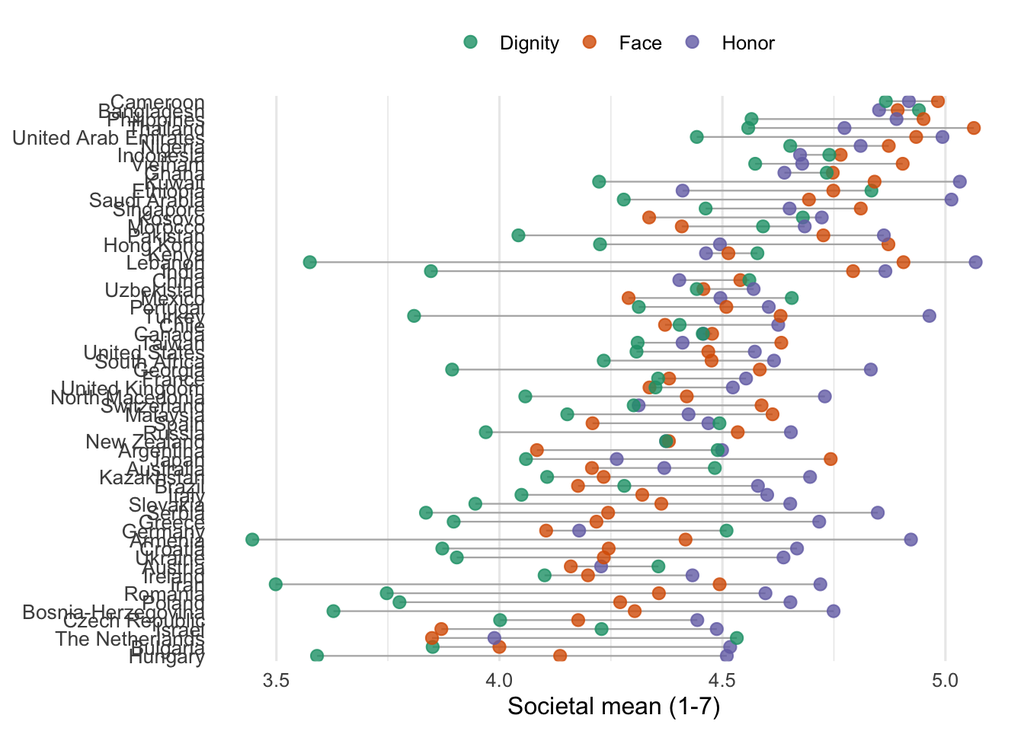

```r
# 1) Reshape to long format (one row per country × dimension)
df_long <- country_norm %>%
  select(
    country_res_full,
    Honor   = H_norm_mean_country,
    Face    = F_norm_mean_country,
    Dignity = D_norm_mean_country
  ) %>%
  pivot_longer(Honor:Dignity, names_to = "Dimension", values_to = "Score")

# 2) Choose how to order countries on the y-axis
#    Option A: by overall mean across the 3 dimensions (lowest → highest)
country_order <- df_long %>%
  group_by(country_res_full) %>%
  summarise(mean_score = mean(Score, na.rm = TRUE), .groups = "drop") %>%
  arrange(mean_score) %>%
  pull(country_res_full)

#    (Alternative)
#    # Option B: by Honor only
#    country_order <- df_long %>% filter(Dimension == "Honor") %>%
#      arrange(Score) %>% pull(country_res_full)
#
#    # Option C: alphabetical
#    country_order <- sort(unique(df_long$country_res_full))

# 3) Apply the order so ggplot respects it
df_long$country_res_full <- factor(df_long$country_res_full, levels = country_order)

# 4) Precompute per-country ranges (min→max across the three dimensions)
ranges <- df_long %>%
  group_by(country_res_full) %>%
  summarise(
    xmin = min(Score, na.rm = TRUE),
    xmax = max(Score, na.rm = TRUE),
    .groups = "drop"
  )

# 5) Plot
p <- ggplot() +
  # grey range bars (min→max per country)
  geom_segment(
    data = ranges,
    aes(x = xmin, xend = xmax, y = country_res_full, yend = country_res_full),
    color = "grey70",
    linewidth = 0.4
  ) +
  # colored points for the three dimensions
  geom_point(
    data = df_long,
    aes(x = Score, y = country_res_full, color = Dimension),
    size = 2.5, alpha = 0.8,
    # Use small vertical jitter if overlapping points are an issue; keep width at 0 for x
    position = position_jitter(height = 0, width = 0)
    # If you prefer perfectly aligned dots, use: position = position_identity()
  ) +
  # Color palette: Dark2 is colorblind-friendly; remove legend title
  scale_color_brewer(palette = "Dark2", name = NULL) +
  labs(x = "Societal mean (1-7)", y = NULL, title = NULL) +
  # Minimal theme + enforce true white background
  theme_minimal(base_size = 12) +
  theme(
    panel.background    = element_rect(fill = "white", color = NA),
    plot.background     = element_rect(fill = "white", color = NA),
    panel.grid.major.y  = element_blank(),     # cleaner y axis
    axis.text.y         = element_text(size = 10),
    legend.position     = "top"
  )

p
```

```r
# 6) Save
#    Adjust height if you have many countries (more rows → more height).
ggsave(
  filename = "figures_robust/DHF_Norms_dotplot_noncentered.png",
  plot = p,
  width = 9, height = 14, dpi = 600
)

# Vector version for journals (crisp text/lines):
ggsave(
  filename = "figures_robust/DHF_Norms_dotplot_noncentered.pdf",
  plot = p,
  width = 9, height = 14
)
```

Cleveland dot plot of Honor/Face/Dignity norms by country (non-centered & centered)

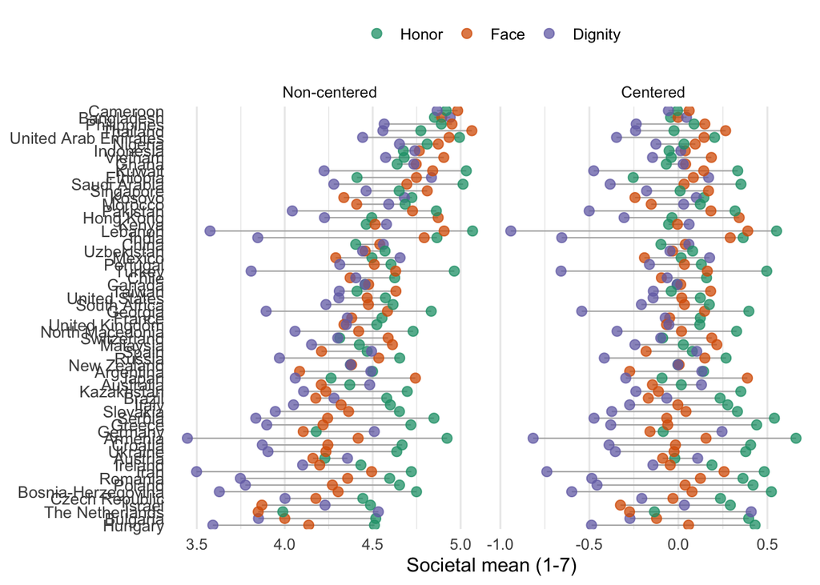

```r
# 1) Long data for NON-centered
df_nc <- country_norm %>%
  select(
    country_res_full,
    Honor   = H_norm_mean_country,
    Face    = F_norm_mean_country,
    Dignity = D_norm_mean_country
  ) %>%
  pivot_longer(Honor:Dignity, names_to = "Dimension", values_to = "Score") %>%
  mutate(Centering = "Non-centered")

# 2) Long data for CENTERED (same dimension names)
df_c <- country_norm %>%
  select(
    country_res_full,
    Honor   = H_normc_mean_country,
    Face    = F_normc_mean_country,
    Dignity = D_normc_mean_country
  ) %>%
  pivot_longer(Honor:Dignity, names_to = "Dimension", values_to = "Score") %>%
  mutate(Centering = "Centered")

# 3) Combine + set factor orders
df_both <- bind_rows(df_nc, df_c) %>%
  mutate(
    Dimension = factor(Dimension, levels = c("Honor","Face","Dignity")),
    Centering = factor(Centering, levels = c("Non-centered","Centered"))
  )

# 4) Fix a single country order (so both facets share the same y-axis)
#    Here: order by the NON-centered average across the 3 dimensions (intuitive baseline)
country_order <- df_nc %>%
  group_by(country_res_full) %>%
  summarise(mean_score = mean(Score, na.rm = TRUE), .groups = "drop") %>%
  arrange(mean_score) %>%
  pull(country_res_full)

df_both$country_res_full <- factor(df_both$country_res_full, levels = country_order)

# 5) (Optional) draw per-country range segments across the 3 dimensions *within each facet*
ranges <- df_both %>%
  group_by(Centering, country_res_full) %>%
  summarise(
    xmin = min(Score, na.rm = TRUE),
    xmax = max(Score, na.rm = TRUE),
    .groups = "drop"
  )

# 6) Plot: one panel per Centering; dots colored by Dimension
set.seed(123)  # reproducible jitter

p <- ggplot() +
  # grey connector showing spread across the three dimensions for each country in each facet
  geom_segment(
    data = ranges,
    aes(x = xmin, xend = xmax, y = country_res_full, yend = country_res_full),
    color = "grey70", linewidth = 0.4
  ) +
  # three dots per country (Honor/Face/Dignity)
  geom_point(
    data = df_both,
    aes(x = Score, y = country_res_full, color = Dimension),
    size = 2.5, alpha = 0.75,
    position = position_jitter(height = 0, width = 0)  # small vertical separation
  ) +
  facet_wrap(~ Centering, nrow = 1, scales = "free_x") +  # free_x lets centered vs non-centered have their own scales
  scale_color_brewer(palette = "Dark2", name = NULL) +
  labs(x = "Societal mean (1-7)", y = NULL, title = NULL) +
  theme_minimal(base_size = 12) +
  theme(
    panel.background   = element_rect(fill = "white", color = NA),
    plot.background    = element_rect(fill = "white", color = NA),
    panel.grid.major.y = element_blank(),
    axis.text.y        = element_text(size = 10),
    legend.position    = "top"
  )

p
```

```r
# 7) Save (increase height for many countries)
ggsave("figures_robust/DHF_Norms_dotplot.png", p,
       width = 18, height = 14, dpi = 600)
ggsave("figures_robust/DHF_Norms_dotplot.pdf", p,
       width = 18, height = 14)
```

World map of Honor/Face/Dignity norms (non-centered scores)

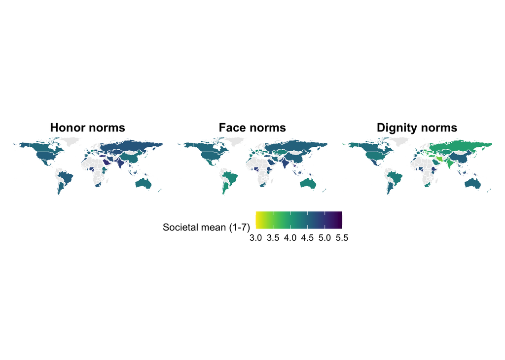

```r
# --- 1) World polygons (drop Antarctica for cleaner view) ---
# Uses Natural Earth country names for joining. Currently in geographic (WGS84) CRS.
# If you want Robinson, add: world <- st_transform(world, "+proj=robin") after this block.
world <- ne_countries(scale = "medium", returnclass = "sf") |>
  select(name, geometry) |>
  filter(name != "Antarctica")

# --- 2) Rename and recode to EXACT Natural Earth names ---
# Harmonize your dataset's country labels to match Natural Earth.
# Add more entries to recode() as mismatches arise.
country_data <- country_norm |>
  transmute(
    name    = country_res_full,
    Honor   = H_norm_mean_country,
    Face    = F_norm_mean_country,
    Dignity = D_norm_mean_country
  ) |>
  mutate(
    name = dplyr::recode(
      name,
      "Bosnia-Herzegovina" = "Bosnia and Herzegovina",
      "Czech Republic"     = "Czechia",
      "The Netherlands"    = "Netherlands",
      "United States"      = "United States of America"
    )
  )

# --- 3) Join to polygons ---
# Left join keeps all polygons; countries without data will map as NA (filled by na.value).
world_join <- world |> left_join(country_data, by = "name")

# (Optional) quickly see if any still unmatched
# Use this to catch remaining naming issues and extend recode() above.
# anti_join(country_data, st_drop_geometry(world), by = "name") |> distinct(name)

# --- 4) Long form + consistent limits across facets (so colors are comparable) ---
# Non-centered scores: keep a single limit across all three to make colors comparable row-wise.
world_long <- world_join |>
  select(geometry, Honor, Face, Dignity) |>
  pivot_longer(c(Honor, Face, Dignity),
               names_to = "Dimension", values_to = "Score") |>
  mutate(Dimension = factor(Dimension, levels = c("Honor","Face","Dignity")))

# Set limits explicitly for reproducibility; alternatively use range(world_long$Score, na.rm=TRUE).
lims <- c(3,5.5) # range(world_long$Score, na.rm = TRUE)

# --- 5) Plot: titles centered, thin white borders, compact legend ---
# Apply the same basic theme to all six maps; legends will later be collected per row.
common_theme <- theme(
  plot.title = element_text(hjust = 0.5, size = 12, face = "bold"),
  legend.position = "bottom",
  legend.title = element_text(size = 10),
  legend.text  = element_text(size = 9)
)

# Non-centered maps (viridis option "C")
p_honor <- ggplot(filter(world_long, Dimension == "Honor")) +
  geom_sf(aes(fill = Score), color = "white", size = 0.1) +
  scale_fill_viridis(name = "Societal mean (1-7)", option = "D",
                     limits = lims, na.value = "grey92", direction = -1) +
  labs(title = "Honor norms") +
  theme_void() +
  common_theme

p_face <- ggplot(filter(world_long, Dimension == "Face")) +
  geom_sf(aes(fill = Score), color = "white", size = 0.1) +
  scale_fill_viridis(name = "Societal mean (1-7)", option = "D",
                     limits = lims, na.value = "grey92", direction = -1) +
  labs(title = "Face norms") +
  theme_void() +
  common_theme

p_dignity <- ggplot(filter(world_long, Dimension == "Dignity")) +
  geom_sf(aes(fill = Score), color = "white", size = 0.1) +
  scale_fill_viridis(name = "Societal mean (1-7)", option = "D",
                     limits = lims, na.value = "grey92", direction = -1) +
  labs(title = "Dignity norms") +
  theme_void() +
  common_theme

# ---- build plot for non-centered scores only ----
p <- (p_honor | p_face | p_dignity) +
  plot_layout(guides = "collect") &
  theme(
    legend.position  = "bottom"
  )
p
```

```r
# Export plot
ggsave("figures_robust/DHF_Norms_worldmap_noncentered.png", p,
       width = 18, height = 4, dpi = 600)
ggsave("figures_robust/DHF_Norms_worldmap_noncentered.pdf", p,
       width = 18, height = 4)
```

World map of Honor/Face/Dignity norms

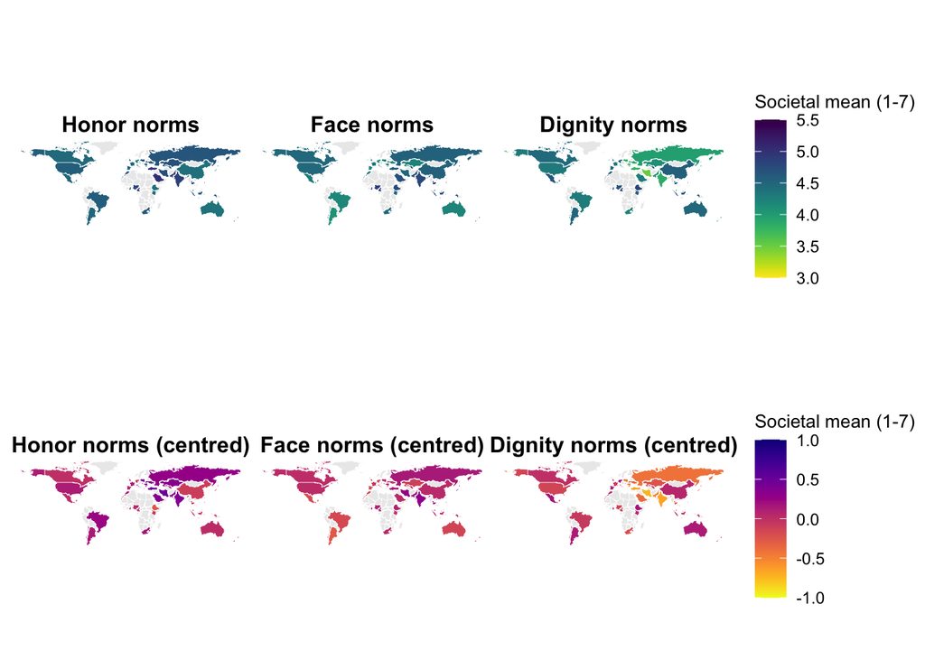

```r
# --- 1) World polygons (drop Antarctica for cleaner view) ---
# Uses Natural Earth country names for joining. Currently in geographic (WGS84) CRS.
# If you want Robinson, add: world <- st_transform(world, "+proj=robin") after this block.
world <- ne_countries(scale = "medium", returnclass = "sf") |>
  select(name, geometry) |>
  filter(name != "Antarctica")

# --- 2) Rename and recode to EXACT Natural Earth names ---
# Harmonize your dataset's country labels to match Natural Earth.
# Add more entries to recode() as mismatches arise.
country_data <- country_norm |>
  transmute(
    name    = country_res_full,
    Honor   = H_norm_mean_country,
    Face    = F_norm_mean_country,
    Dignity = D_norm_mean_country,
    HonorC   = H_normc_mean_country,
    FaceC    = F_normc_mean_country,
    DignityC = D_normc_mean_country,
  ) |>
  mutate(
    name = dplyr::recode(
      name,
      "Bosnia-Herzegovina" = "Bosnia and Herzegovina",
      "Czech Republic"     = "Czechia",
      "The Netherlands"    = "Netherlands",
      "United States"      = "United States of America"
    )
  )

# --- 3) Join to polygons ---
# Left join keeps all polygons; countries without data will map as NA (filled by na.value).
world_join <- world |> left_join(country_data, by = "name")

# (Optional) quickly see if any still unmatched
# Use this to catch remaining naming issues and extend recode() above.
# anti_join(country_data, st_drop_geometry(world), by = "name") |> distinct(name)

# --- 4) Long form + consistent limits across facets (so colors are comparable) ---
# Non-centered scores: keep a single limit across all three to make colors comparable row-wise.
world_long <- world_join |>
  select(geometry, Honor, Face, Dignity) |>
  pivot_longer(c(Honor, Face, Dignity),
               names_to = "Dimension", values_to = "Score") |>
  mutate(Dimension = factor(Dimension, levels = c("Honor","Face","Dignity")))

# Set limits explicitly for reproducibility; alternatively use range(world_long$Score, na.rm=TRUE).
lims <- c(3,5.5) # range(world_long$Score, na.rm = TRUE)

# Centered scores: keep them separate (different palette/legend) and use symmetric limits if possible.
world_long_centered <- world_join |>
  select(geometry, HonorC, FaceC, DignityC) |>
  pivot_longer(c(HonorC, FaceC, DignityC),
               names_to = "Dimension", values_to = "Score") |>
  mutate(Dimension = factor(Dimension, levels = c("HonorC","FaceC","DignityC")))

# Prefer symmetric bounds around 0 for interpretability (edit as needed).
limsc <- c(-1,1) # range(world_long_centered$Score, na.rm = TRUE)

# --- 5) Plot: titles centered, thin white borders, compact legend ---
# Apply the same basic theme to all six maps; legends will later be collected per row.
common_theme <- theme(
  plot.title = element_text(hjust = 0.5, size = 12, face = "bold"),
  legend.position = "bottom",
  legend.title = element_text(size = 10),
  legend.text  = element_text(size = 9)
)

# Non-centered maps (viridis option "C")
p_honor <- ggplot(filter(world_long, Dimension == "Honor")) +
  geom_sf(aes(fill = Score), color = "white", size = 0.1) +
  scale_fill_viridis(name = "Societal mean (1-7)", option = "D",
                     limits = lims, na.value = "grey92", direction = -1) +
  labs(title = "Honor norms") +
  theme_void() +
  common_theme

p_face <- ggplot(filter(world_long, Dimension == "Face")) +
  geom_sf(aes(fill = Score), color = "white", size = 0.1) +
  scale_fill_viridis(name = "Societal mean (1-7)", option = "D",
                     limits = lims, na.value = "grey92", direction = -1) +
  labs(title = "Face norms") +
  theme_void() +
  common_theme

p_dignity <- ggplot(filter(world_long, Dimension == "Dignity")) +
  geom_sf(aes(fill = Score), color = "white", size = 0.1) +
  scale_fill_viridis(name = "Societal mean (1-7)", option = "D",
                     limits = lims, na.value = "grey92", direction = -1) +
  labs(title = "Dignity norms") +
  theme_void() +
  common_theme

# Centered maps (viridis option "D" to visually differentiate from non-centered)
p_honorc <- ggplot(filter(world_long_centered, Dimension == "HonorC")) +
  geom_sf(aes(fill = Score), color = "white", size = 0.1) +
  scale_fill_viridis(name = "Societal mean (1-7)", option = "C",
                     limits = limsc, na.value = "grey92", direction = -1) +
  labs(title = "Honor norms (centred)") +
  theme_void() +
  common_theme

p_facec <- ggplot(filter(world_long_centered, Dimension == "FaceC")) +
  geom_sf(aes(fill = Score), color = "white", size = 0.1) +
  scale_fill_viridis(name = "Societal mean (1-7)", option = "C",
                     limits = limsc, na.value = "grey92", direction = -1) +
  labs(title = "Face norms (centred)") +
  theme_void() +
  common_theme

p_dignityc <- ggplot(filter(world_long_centered, Dimension == "DignityC")) +
  geom_sf(aes(fill = Score), color = "white", size = 0.1) +
  scale_fill_viridis(name = "Societal mean (1-7)", option = "C",
                     limits = limsc, na.value = "grey92", direction = -1) +
  labs(title = "Dignity norms (centred)") +
  theme_void() +
  common_theme

# ---- build two separate rows (each with its own collected legend) ----
# Keep guide collection INSIDE each row so the top row (C) and bottom row (D)
# retain different palettes and their own legends.
row_nc <- (p_honor | p_face | p_dignity) +
  plot_layout(guides = "collect") &
  theme(
    legend.position = "right",          # put legend to the side of the row
    legend.direction = "vertical"       # vertical legend for compact height
  )

row_c <- (p_honorc | p_facec | p_dignityc) +
  plot_layout(guides = "collect") &
  theme(
    legend.position = "right",
    legend.direction = "vertical"
  )

# Final assembly: stack the two rows. Each keeps its own legend and color scale.
final_plot <- row_nc / row_c
final_plot
```

```r
# Export plot
ggsave("figures_robust/DHF_Norms_worldmap.png", final_plot,
       width = 18, height = 6, dpi = 600)
ggsave("figures_robust/DHF_Norms_worldmap.pdf", final_plot,
       width = 18, height = 6)
```

### Main study: Country-level correlates of DHF

Ecological antecedents of DHF endorsement and norms

```r
apaTables::apa.cor.table(
  dt4 %>%
    select(D_normc_mean_country, H_normc_mean_country,
           F_normc_mean_country, D_endc_mean_country,
           H_endc_mean_country, F_endc_mean_country,
           wb_pop_density_1961, ms_pathogen_9items,
           icb_crisis_participations, icb_avg_violence_level,
           wb_gdp_pcap_usd_1960, fiw_F_2013,
           fiw_C_2013, fiw_Total_2013
           )
)
```

```
##
##
## Means, standard deviations, and correlations with confidence intervals
##
##
##   Variable                     M      SD     1            2
##   1. D_normc_mean_country      -0.23  0.27
##
##   2. H_normc_mean_country      0.20   0.21   -.86**
##                                              [-.86, -.85]
##
##   3. F_normc_mean_country      0.03   0.14   -.64**       .15**
##                                              [-.65, -.63] [.14, .16]
##
##   4. D_endc_mean_country       0.72   0.25   .26**        .07**
##                                              [.24, .27]   [.06, .09]
##
##   5. H_endc_mean_country       -0.30  0.15   -.68**       .63**
##                                              [-.69, -.68] [.62, .64]
##
##   6. F_endc_mean_country       -0.42  0.21   .17**        -.53**
##                                              [.16, .18]   [-.54, -.52]
##
##   7. wb_pop_density_1961       134.50 394.66 .01          -.15**
##                                              [-.01, .02]  [-.16, -.14]
##
##   8. ms_pathogen_9items        -0.09  0.63   -.05**       -.11**
##                                              [-.06, -.04] [-.12, -.10]
##
##   9. icb_crisis_participations 21.68  21.89  -.04**       .05**
##                                              [-.05, -.02] [.04, .07]
##
##   10. icb_avg_violence_level   2.05   0.48   .17**        -.19**
##                                              [.16, .19]   [-.20, -.17]
##
##   11. wb_gdp_pcap_usd_1960     932.30 963.90 .39**        -.24**
##                                              [.38, .40]   [-.25, -.22]
##
##   12. fiw_F_2013               9.91   4.27   .33**        -.16**
##                                              [.32, .35]   [-.17, -.14]
```

[output cut: 83 more lines]

```
##   [.21, .24] [-.01, .02]  [.68, .70]
##
##   .12**      -.09**       .64**      .92**
##   [.11, .14] [-.11, -.08] [.63, .65] [.92, .93]
##
##   .15**      -.12**       .65**      .94**      .95**
##   [.13, .16] [-.14, -.11] [.64, .66] [.94, .94] [.95, .95]
##
##
## Note. M and SD are used to represent mean and standard deviation, respectively.
## Values in square brackets indicate the 95% confidence interval.
## The confidence interval is a plausible range of population correlations
## that could have caused the sample correlation (Cumming, 2014).
##  * indicates p < .05. ** indicates p < .01.
##
```

DHF and current country performance

```r
apaTables::apa.cor.table(
  dt4 %>%
    select(D_normc_mean_country, H_normc_mean_country,
           F_normc_mean_country, D_endc_mean_country,
           H_endc_mean_country, F_endc_mean_country,
           wb_gdp_pcap_usd_most_recent, gii_value_2021,
           wb_gini_2020, fiw_Total_2023, hdi_value_2021
           )
)
```

```
##
##
## Means, standard deviations, and correlations with confidence intervals
##
##
##   Variable                       M        SD       1            2
##   1. D_normc_mean_country        -0.23    0.27
##
##   2. H_normc_mean_country        0.20     0.21     -.86**
##                                                    [-.86, -.85]
##
##   3. F_normc_mean_country        0.03     0.14     -.64**       .15**
##                                                    [-.65, -.63] [.14, .16]
##
##   4. D_endc_mean_country         0.72     0.25     .26**        .07**
##                                                    [.24, .27]   [.06, .09]
##
##   5. H_endc_mean_country         -0.30    0.15     -.68**       .63**
##                                                    [-.69, -.68] [.62, .64]
##
##   6. F_endc_mean_country         -0.42    0.21     .17**        -.53**
##                                                    [.16, .18]   [-.54, -.52]
##
##   7. wb_gdp_pcap_usd_most_recent 26476.17 24537.98 .43**        -.35**
##                                                    [.42, .44]   [-.36, -.34]
##
##   8. gii_value_2021              0.22     0.16     -.18**       -.03**
##                                                    [-.19, -.17] [-.04, -.01]
##
##   9. wb_gini_2020                34.90    5.35     .45**        -.40**
##                                                    [.43, .46]   [-.42, -.39]
##
##   10. fiw_Total_2023             66.24    26.44    .40**        -.20**
##                                                    [.39, .41]   [-.21, -.19]
##
##   11. hdi_value_2021             0.83     0.11     .17**        -.00
##                                                    [.15, .18]   [-.01, .01]
##
##   3            4            5            6            7            8
##
```

[output cut: 56 more lines]

```
##
##
##   .01
##   [-.01, .03]
##
##   -.05**       .61**
##   [-.07, -.04] [.60, .62]
##
##
## Note. M and SD are used to represent mean and standard deviation, respectively.
## Values in square brackets indicate the 95% confidence interval.
## The confidence interval is a plausible range of population correlations
## that could have caused the sample correlation (Cumming, 2014).
##  * indicates p < .05. ** indicates p < .01.
##
```

DHF and other cultural dimensions

```r
# believe these are mean_country centered above, but should check
apaTables::apa.cor.table(
  dt4 %>%
    select(D_normc_mean_country, H_normc_mean_country,
           F_normc_mean_country, D_endc_mean_country,
           H_endc_mean_country, F_endc_mean_country,
           # Openness_to_Change_mean_country,
           Openness_to_Change,
           # Conservation_mean_country,
           Conservation,
           # Self_Transcendence_mean_country,
           Self_Transcendence,
           # Self_Enhancement_mean_country,
           Self_Enhancement,
           tl_tightness, mk_individualism_collectivism,
           mk_flexibility_monumentalism, rm_relational_mobility
           # `o-c`, `st-se`
           # not sure what these are need to update var names
           )
)
```

```
##
##
## Means, standard deviations, and correlations with confidence intervals
##
##
##   Variable                          M      SD    1            2
##   1. D_normc_mean_country           -0.23  0.27
##
##   2. H_normc_mean_country           0.20   0.21  -.86**
##                                                  [-.86, -.85]
##
##   3. F_normc_mean_country           0.03   0.14  -.64**       .15**
##                                                  [-.65, -.63] [.14, .16]
##
##   4. D_endc_mean_country            0.72   0.25  .26**        .07**
##                                                  [.24, .27]   [.06, .09]
##
##   5. H_endc_mean_country            -0.30  0.15  -.68**       .63**
##                                                  [-.69, -.68] [.62, .64]
##
##   6. F_endc_mean_country            -0.42  0.21  .17**        -.53**
##                                                  [.16, .18]   [-.54, -.52]
##
##   7. Openness_to_Change             4.39   0.87  -.01         -.02**
##                                                  [-.03, .00]  [-.04, -.01]
##
##   8. Conservation                   4.11   0.88  -.00         -.07**
##                                                  [-.02, .01]  [-.09, -.06]
##
##   9. Self_Transcendence             4.88   0.77  .04**        .01
##                                                  [.02, .05]   [-.00, .02]
##
##   10. Self_Enhancement              4.04   1.05  -.04**       -.04**
##                                                  [-.05, -.02] [-.05, -.02]
##
##   11. tl_tightness                  1.93   0.24  -.18**       -.14**
##                                                  [-.19, -.16] [-.15, -.12]
##
##   12. mk_individualism_collectivism -21.15 86.56 .26**        -.06**
##                                                  [.25, .27]   [-.08, -.05]
```

[output cut: 83 more lines]

```
##   [-.01, .02]  [-.16, -.13] [-.54, -.52]
##
##   -.12**       -.04**       -.13**       .57**
##   [-.14, -.11] [-.05, -.03] [-.15, -.12] [.57, .58]
##
##   .18**        -.02*        -.34**       .29**      -.30**
##   [.16, .19]   [-.04, -.00] [-.35, -.32] [.28, .31] [-.32, -.29]
##
##
## Note. M and SD are used to represent mean and standard deviation, respectively.
## Values in square brackets indicate the 95% confidence interval.
## The confidence interval is a plausible range of population correlations
## that could have caused the sample correlation (Cumming, 2014).
##  * indicates p < .05. ** indicates p < .01.
##
```

### Main study: Individual-level correlates of DHF

#### DHF and prosociality

[Tables in line with prereg H2-H3]

```r
# ============================================================================
# H2 ANALYSIS USING dt5 (PROSOCIAL OUTCOME)
# ============================================================================

# reset dt5 so that we have all the variables
dt5 <- subset(dt4, dictator_cpass==1)
dt5$prosocial <- as.numeric(dt5$Dictator_decision)

print("Preparing H2 analysis with misty centering")
```

```
## [1] "Preparing H2 analysis with misty centering"
```

```r
print(paste("Dataset has", nrow(dt5), "participants"))
```

```
## [1] "Dataset has 20653 participants"
```

```r
# Proper multilevel centering using misty package
DF_H2 <- dt5 %>%
  mutate(
    # Group-mean centering for individual-level variables (Level 1)
    D_self_end_CWC = center(D_self_end, type = "CWC", cluster = country_res_full),
    D_other_end_CWC = center(D_other_end, type = "CWC", cluster = country_res_full),
    H_self_end_CWC = center(H_self_end, type = "CWC", cluster = country_res_full),
    H_other_end_CWC = center(H_other_end, type = "CWC", cluster = country_res_full),
    F_self_end_CWC = center(F_self_end, type = "CWC", cluster = country_res_full),
    F_other_end_CWC = center(F_other_end, type = "CWC", cluster = country_res_full)
  )

# Data quality check
print("Data quality check...")
```

```
## [1] "Data quality check..."
```

```r
analysis_vars <- c("prosocial", "D_self_end_CWC", "D_other_end_CWC",
                   "H_self_end_CWC", "H_other_end_CWC",
                   "F_self_end_CWC", "F_other_end_CWC", "country_res_full")

# Check which variables exist
available_vars <- analysis_vars[analysis_vars %in% names(DF_H2)]
print("Available analysis variables:")
```

```
## [1] "Available analysis variables:"
```

```r
print(available_vars)
```

```
## [1] "prosocial"        "D_self_end_CWC"   "D_other_end_CWC"  "H_self_end_CWC"
## [5] "H_other_end_CWC"  "F_self_end_CWC"   "F_other_end_CWC"  "country_res_full"
```

```r
# Complete cases
complete_cases <- sum(complete.cases(DF_H2[, available_vars]))
print(paste("Complete cases for analysis:", complete_cases, "out of", nrow(DF_H2)))
```

```
## [1] "Complete cases for analysis: 20653 out of 20653"
```

```r
# Country sample sizes
country_sizes <- DF_H2 %>%
  filter(!is.na(prosocial)) %>%
  group_by(country_res_full) %>%
  summarise(n = n()) %>%
  arrange(desc(n))

print("Sample sizes by country (top 10):")
```

```
## [1] "Sample sizes by country (top 10):"
```

```r
print(head(country_sizes, 10))
```

```
## # A tibble: 10 × 2
##    country_res_full     n
##    <fct>            <int>
##  1 Turkey            1722
##  2 United States     1392
##  3 Australia          818
##  4 Philippines        729
##  5 Germany            670
##  6 Canada             640
##  7 Croatia            627
##  8 Poland             626
##  9 Italy              532
## 10 United Kingdom     457
```

```r
print(paste("Number of countries:", nrow(country_sizes)))
```

```
## [1] "Number of countries: 63"
```

```r
print(paste("Minimum country sample size:", min(country_sizes$n)))
```

```
## [1] "Minimum country sample size: 30"
```

```r
# H2 Main Analysis - six factors model
print("\nRunning H2 Analysis - Six DHF Facets Model...")
```

```
## [1] "\nRunning H2 Analysis - Six DHF Facets Model..."
```

```r
h2.fit <- lmer(prosocial ~ D_self_end_CWC + D_other_end_CWC +
                 H_self_end_CWC + H_other_end_CWC +
                 F_self_end_CWC + F_other_end_CWC +
                 (1|country_res_full),
               data = DF_H2,
               REML = FALSE)

print("H2 MODEL RESULTS:")
```

```
## [1] "H2 MODEL RESULTS:"
```

```r
h2_params <- parameters(h2.fit, standardize = "refit", ci = 0.95)
print(h2_params)
```

```
## # Fixed Effects
##
## Parameter       | Coefficient |       SE |         95% CI | t(20644) |      p
## -----------------------------------------------------------------------------
## (Intercept)     |        0.02 |     0.02 | [-0.03,  0.06] |     0.65 | 0.516
## D self end CWC  |   -3.58e-03 | 7.70e-03 | [-0.02,  0.01] |    -0.47 | 0.642
## D other end CWC |        0.08 | 7.70e-03 | [ 0.06,  0.09] |    10.37 | < .001
## H self end CWC  |       -0.03 | 8.33e-03 | [-0.04, -0.01] |    -3.22 | 0.001
## H other end CWC |       -0.01 | 9.38e-03 | [-0.03,  0.01] |    -1.35 | 0.176
## F self end CWC  |       -0.03 | 9.25e-03 | [-0.04, -0.01] |    -2.72 | 0.006
## F other end CWC |        0.04 | 9.06e-03 | [ 0.03,  0.06] |     4.84 | < .001
##
## # Random Effects
##
## Parameter                        | Coefficient
## ----------------------------------------------
## SD (Intercept: country_res_full) |        0.18
## SD (Residual)                    |        0.99
```

```
##
## Uncertainty intervals (equal-tailed) and p-values (two-tailed) computed
##   using a Wald t-distribution approximation. Uncertainty intervals for
##   random effect variances computed using a Wald z-distribution
##   approximation.
```

```r
# Model performance
print("\nModel Performance:")
```

```
## [1] "\nModel Performance:"
```

```r
perf <- performance(h2.fit)
```

```
## Model was not fitted with REML, however, `estimator = "REML"`. Set
##   `estimator = "ML"` to obtain identical results as from `AIC()`.
```

```r
print(perf)
```

```
## # Indices of model performance
##
## AIC     |    AICc |     BIC | R2 (cond.) | R2 (marg.) |   ICC |  RMSE | Sigma
## -----------------------------------------------------------------------------
## 81079.3 | 81079.3 | 81150.7 |      0.039 |      0.008 | 0.031 | 1.712 | 1.715
```

```r
# R-squared values
r2_vals <- r2(h2.fit)
print(paste("Marginal R² (fixed effects):", round(r2_vals$R2_marginal, 3)))
```

```
## [1] "Marginal R² (fixed effects): 0.008"
```

```r
print(paste("Conditional R² (fixed + random):", round(r2_vals$R2_conditional, 3)))
```

```
## [1] "Conditional R² (fixed + random): 0.039"
```

```r
# Check column names and create standardized results table
print("\nColumn names in h2_params:")
```

```
## [1] "\nColumn names in h2_params:"
```

```r
print(names(h2_params))
```

```
##  [1] "Parameter"   "Coefficient" "SE"          "CI"          "CI_low"
##  [6] "CI_high"     "t"           "df_error"    "p"           "Effects"
## [11] "Group"
```

```r
# Create standardized results table with proper column references
print("\nStandardized Coefficients with 95% CI and p-values:")
```

```
## [1] "\nStandardized Coefficients with 95% CI and p-values:"
```

```r
h2_results <- data.frame(
  Parameter = h2_params$Parameter,
  Std_Beta = round(h2_params$Coefficient, 4),  # Using Coefficient instead of Std_Coefficient
  CI_Lower = round(h2_params$CI_low, 4),
  CI_Upper = round(h2_params$CI_high, 4),
  p_value = round(h2_params$p, 4),
  Significance = ifelse(h2_params$p < 0.001, "***",
                        ifelse(h2_params$p < 0.01, "**",
                               ifelse(h2_params$p < 0.05, "*", "")))
)
print(h2_results)
```

```
##           Parameter Std_Beta CI_Lower CI_Upper p_value Significance
## 1       (Intercept)   0.0156  -0.0315   0.0628  0.5155
## 2    D_self_end_CWC  -0.0036  -0.0187   0.0115  0.6418
## 3   D_other_end_CWC   0.0799   0.0648   0.0950  0.0000          ***
## 4    H_self_end_CWC  -0.0269  -0.0432  -0.0105  0.0013           **
## 5   H_other_end_CWC  -0.0127  -0.0311   0.0057  0.1760
## 6    F_self_end_CWC  -0.0252  -0.0433  -0.0071  0.0064           **
## 7   F_other_end_CWC   0.0439   0.0261   0.0617  0.0000          ***
## 8    SD (Intercept)   0.1775       NA       NA      NA         <NA>
## 9 SD (Observations)   0.9851       NA       NA      NA         <NA>
```

```r
# Random effects
rand_effects <- VarCorr(h2.fit)
print("\nRandom Effects Variance:")
```

```
## [1] "\nRandom Effects Variance:"
```

```r
print(rand_effects)
```

```
##  Groups           Name        Std.Dev.
##  country_res_full (Intercept) 0.30885
##  Residual                     1.71451
```

```r
# ============================================================================
# H3 ANALYSIS - MULTILEVEL PATH MODELS
# ===========================================================================

# STEP 1: Prepare prosocial data (dt5) with proper misty centering
print("Preparing prosocial model data from dt5...")
```

```
## [1] "Preparing prosocial model data from dt5..."
```

```r
DF_prosocial_H3 <- dt5 %>%
  filter(!is.na(prosocial) & !is.na(D_end) & !is.na(H_end) & !is.na(F_end) &
           !is.na(D_norm_mean_country) & !is.na(H_norm_mean_country) & !is.na(F_norm_mean_country)) %>%
  mutate(
    # Individual-level variables: group-mean centering (CWC)
    D_end_CWC = center(D_end, type = "CWC", cluster = country_res_full),
    H_end_CWC = center(H_end, type = "CWC", cluster = country_res_full),
    F_end_CWC = center(F_end, type = "CWC", cluster = country_res_full),

    # Country-level variables: grand-mean centering (CGM)
    D_norm_agg_CGM = center(D_norm_mean_country, type = "CGM"),
    H_norm_agg_CGM = center(H_norm_mean_country, type = "CGM"),
    F_norm_agg_CGM = center(F_norm_mean_country, type = "CGM")
  )

print(paste("Prosocial model sample size:", nrow(DF_prosocial_H3)))
```

```
## [1] "Prosocial model sample size: 20653"
```

```r
# STEP 2: Prepare reciprocity data (dt6) with proper misty centering
# reset dt6 since it doesn't have these variables
dt6 <- subset(dt4, ultimatum_cpass==1) #N=20626

# Merge with dt6
dt6 <- merge(dt6, neg_rec_df, by="ResponseId")
dt6$UG_negrec <- as.numeric(dt6$UG_negrec)
dt6 <- merge(dt6, pos_rec_df, by="ResponseId")

print("Preparing reciprocity model data from dt6...")
```

```
## [1] "Preparing reciprocity model data from dt6..."
```

```r
DF_reciprocity_H3 <- dt6 %>%
  filter(!is.na(UG_posrec) & !is.na(UG_negrec) &
           !is.na(D_end) & !is.na(H_end) & !is.na(F_end) &
           !is.na(D_norm_mean_country) & !is.na(H_norm_mean_country) & !is.na(F_norm_mean_country)) %>%
  mutate(
    # Individual-level variables: group-mean centering (CWC)
    D_end_CWC = center(D_end, type = "CWC", cluster = country_res_full),
    H_end_CWC = center(H_end, type = "CWC", cluster = country_res_full),
    F_end_CWC = center(F_end, type = "CWC", cluster = country_res_full),

    # Country-level variables: grand-mean centering (CGM)
    D_norm_agg_CGM = center(D_norm_mean_country, type = "CGM"),
    H_norm_agg_CGM = center(H_norm_mean_country, type = "CGM"),
    F_norm_agg_CGM = center(F_norm_mean_country, type = "CGM")
  )

print(paste("Reciprocity model sample size:", nrow(DF_reciprocity_H3)))
```

```
## [1] "Reciprocity model sample size: 19744"
```

```r
# STEP 3: H3 Model 1 - Prosocial Behavior
print("\nRunning H3 Model 1: Prosocial Behavior...")
```

```
## [1] "\nRunning H3 Model 1: Prosocial Behavior..."
```

```r
prosocial.model <- '
# Level 1: Individual endorsement predicting prosocial behavior
prosocial ~ D_end_CWC + H_end_CWC + F_end_CWC

# Level 2: Country-level norms predicting prosocial behavior
prosocial ~ D_norm_agg_CGM + H_norm_agg_CGM + F_norm_agg_CGM
'

prosocial.fit <- sem(
  model = prosocial.model,
  data = DF_prosocial_H3,
  cluster = "country_res_full"
)

print("PROSOCIAL MODEL RESULTS:")
```

```
## [1] "PROSOCIAL MODEL RESULTS:"
```

```r
print(summary(prosocial.fit, standardized = TRUE, fit.measures = TRUE, rsquare = TRUE))
```

```
## lavaan 0.6-21 ended normally after 1 iteration
##
##   Estimator                                         ML
##   Optimization method                           NLMINB
##   Number of model parameters                         8
##
##   Number of observations                         20653
##   Number of clusters [country_res_full]             63
##
## Model Test User Model:
##                                               Standard      Scaled
##   Test Statistic                                 0.000       0.000
##   Degrees of freedom                                 0           0
##
## Model Test Baseline Model:
##
##   Test statistic                               189.876      39.133
##   Degrees of freedom                                 6           6
##   P-value                                        0.000       0.000
##   Scaling correction factor                                  4.852
##
## User Model versus Baseline Model:
##
##   Comparative Fit Index (CFI)                    1.000       1.000
##   Tucker-Lewis Index (TLI)                       1.000       1.000
##
##   Robust Comparative Fit Index (CFI)                            NA
##   Robust Tucker-Lewis Index (TLI)                               NA
##
## Loglikelihood and Information Criteria:
##
##   Loglikelihood user model (H0)             -40654.777  -40654.777
##   Loglikelihood unrestricted model (H1)     -40654.777  -40654.777
##
##   Akaike (AIC)                               81325.554   81325.554
##   Bayesian (BIC)                             81389.039   81389.039
##   Sample-size adjusted Bayesian (SABIC)      81363.615   81363.615
##
## Root Mean Square Error of Approximation:
##
```

[output cut: 28 more lines]

```
##     D_norm_agg_CGM    0.366    0.106    3.454    0.001    0.366    0.072
##     H_norm_agg_CGM    0.676    0.196    3.452    0.001    0.676    0.082
##     F_norm_agg_CGM   -0.413    0.185   -2.229    0.026   -0.413   -0.063
##
## Intercepts:
##                    Estimate  Std.Err  z-value  P(>|z|)   Std.lv  Std.all
##    .prosocial         4.764    0.033  146.422    0.000    4.764    2.737
##
## Variances:
##                    Estimate  Std.Err  z-value  P(>|z|)   Std.lv  Std.all
##    .prosocial         3.001    0.145   20.669    0.000    3.001    0.991
##
## R-Square:
##                    Estimate
##     prosocial         0.009
```

```r
# Extract standardized results for prosocial model
prosocial_std <- standardizedSolution(prosocial.fit, ci = TRUE, level = 0.95)
prosocial_reg <- prosocial_std[prosocial_std$op == "~",]
print("\nStandardized Coefficients with 95% CI:")
```

```
## [1] "\nStandardized Coefficients with 95% CI:"
```

```r
prosocial_results <- data.frame(
  Parameter = prosocial_reg$rhs,
  Std_Beta = round(prosocial_reg$est.std, 4),
  CI_Lower = round(prosocial_reg$ci.lower, 4),
  CI_Upper = round(prosocial_reg$ci.upper, 4),
  p_value = round(prosocial_reg$pvalue, 4),
  Significance = ifelse(prosocial_reg$pvalue < 0.001, "***",
                        ifelse(prosocial_reg$pvalue < 0.01, "**",
                               ifelse(prosocial_reg$pvalue < 0.05, "*", "")))
)
print(prosocial_results)
```

```
##        Parameter Std_Beta CI_Lower CI_Upper p_value Significance
## 1      D_end_CWC   0.0663   0.0417   0.0909  0.0000          ***
## 2      H_end_CWC  -0.0463  -0.0636  -0.0289  0.0000          ***
## 3      F_end_CWC   0.0263   0.0094   0.0431  0.0023           **
## 4 D_norm_agg_CGM   0.0724   0.0319   0.1130  0.0005          ***
## 5 H_norm_agg_CGM   0.0820   0.0353   0.1288  0.0006          ***
## 6 F_norm_agg_CGM  -0.0628  -0.1183  -0.0073  0.0264            *
```

```r
# STEP 4: H3 Model 2 - Positive Reciprocity
print("\nRunning H3 Model 2: Positive Reciprocity...")
```

```
## [1] "\nRunning H3 Model 2: Positive Reciprocity..."
```

```r
posrec.model <- '
# Level 1: Individual endorsement predicting positive reciprocity
UG_posrec ~ D_end_CWC + H_end_CWC + F_end_CWC

# Level 2: Country-level norms predicting positive reciprocity
UG_posrec ~ D_norm_agg_CGM + H_norm_agg_CGM + F_norm_agg_CGM
'

posrec.fit <- sem(
  model = posrec.model,
  data = DF_reciprocity_H3,
  cluster = "country_res_full"
)

print("POSITIVE RECIPROCITY MODEL RESULTS:")
```

```
## [1] "POSITIVE RECIPROCITY MODEL RESULTS:"
```

```r
print(summary(posrec.fit, standardized = TRUE, fit.measures = TRUE, rsquare = TRUE))
```

```
## lavaan 0.6-21 ended normally after 1 iteration
##
##   Estimator                                         ML
##   Optimization method                           NLMINB
##   Number of model parameters                         8
##
##   Number of observations                         19744
##   Number of clusters [country_res_full]             63
##
## Model Test User Model:
##                                               Standard      Scaled
##   Test Statistic                                 0.000       0.000
##   Degrees of freedom                                 0           0
##
## Model Test Baseline Model:
##
##   Test statistic                               127.126      42.073
##   Degrees of freedom                                 6           6
##   P-value                                        0.000       0.000
##   Scaling correction factor                                  3.022
##
## User Model versus Baseline Model:
##
##   Comparative Fit Index (CFI)                    1.000       1.000
##   Tucker-Lewis Index (TLI)                       1.000       1.000
##
##   Robust Comparative Fit Index (CFI)                            NA
##   Robust Tucker-Lewis Index (TLI)                               NA
##
## Loglikelihood and Information Criteria:
##
##   Loglikelihood user model (H0)             -92624.030  -92624.030
##   Loglikelihood unrestricted model (H1)     -92624.030  -92624.030
##
##   Akaike (AIC)                              185264.061  185264.061
##   Bayesian (BIC)                            185327.185  185327.185
##   Sample-size adjusted Bayesian (SABIC)     185301.762  185301.762
##
## Root Mean Square Error of Approximation:
##
```

[output cut: 28 more lines]

```
##     D_norm_agg_CGM   -0.871    1.564   -0.557    0.578   -0.871   -0.011
##     H_norm_agg_CGM    0.059    2.832    0.021    0.983    0.059    0.000
##     F_norm_agg_CGM    2.835    2.268    1.250    0.211    2.835    0.028
##
## Intercepts:
##                    Estimate  Std.Err  z-value  P(>|z|)   Std.lv  Std.all
##    .UG_posrec        74.227    0.377  196.852    0.000   74.227    2.806
##
## Variances:
##                    Estimate  Std.Err  z-value  P(>|z|)   Std.lv  Std.all
##    .UG_posrec       695.494    8.649   80.417    0.000  695.494    0.994
##
## R-Square:
##                    Estimate
##     UG_posrec         0.006
```

```r
# Extract standardized results for positive reciprocity model
posrec_std <- standardizedSolution(posrec.fit, ci = TRUE, level = 0.95)
posrec_reg <- posrec_std[posrec_std$op == "~",]
print("\nStandardized Coefficients with 95% CI:")
```

```
## [1] "\nStandardized Coefficients with 95% CI:"
```

```r
posrec_results <- data.frame(
  Parameter = posrec_reg$rhs,
  Std_Beta = round(posrec_reg$est.std, 4),
  CI_Lower = round(posrec_reg$ci.lower, 4),
  CI_Upper = round(posrec_reg$ci.upper, 4),
  p_value = round(posrec_reg$pvalue, 4),
  Significance = ifelse(posrec_reg$pvalue < 0.001, "***",
                        ifelse(posrec_reg$pvalue < 0.01, "**",
                               ifelse(posrec_reg$pvalue < 0.05, "*", "")))
)
print(posrec_results)
```

```
##        Parameter Std_Beta CI_Lower CI_Upper p_value Significance
## 1      D_end_CWC   0.0662   0.0520   0.0803  0.0000          ***
## 2      H_end_CWC  -0.0391  -0.0558  -0.0224  0.0000          ***
## 3      F_end_CWC   0.0435   0.0216   0.0654  0.0001          ***
## 4 D_norm_agg_CGM  -0.0114  -0.0514   0.0287  0.5775
## 5 H_norm_agg_CGM   0.0005  -0.0441   0.0451  0.9834
## 6 F_norm_agg_CGM   0.0283  -0.0161   0.0728  0.2116
```

```r
# STEP 5: H3 Model 3 - Negative Reciprocity
print("\nRunning H3 Model 3: Negative Reciprocity...")
```

```
## [1] "\nRunning H3 Model 3: Negative Reciprocity..."
```

```r
negrec.model <- '
# Level 1: Individual endorsement predicting negative reciprocity
UG_negrec ~ D_end_CWC + H_end_CWC + F_end_CWC

# Level 2: Country-level norms predicting negative reciprocity
UG_negrec ~ D_norm_agg_CGM + H_norm_agg_CGM + F_norm_agg_CGM
'

negrec.fit <- sem(
  model = negrec.model,
  data = DF_reciprocity_H3,
  cluster = "country_res_full"
)

print("NEGATIVE RECIPROCITY MODEL RESULTS:")
```

```
## [1] "NEGATIVE RECIPROCITY MODEL RESULTS:"
```

```r
print(summary(negrec.fit, standardized = TRUE, fit.measures = TRUE, rsquare = TRUE))
```

```
## lavaan 0.6-21 ended normally after 1 iteration
##
##   Estimator                                         ML
##   Optimization method                           NLMINB
##   Number of model parameters                         8
##
##   Number of observations                         19744
##   Number of clusters [country_res_full]             63
##
## Model Test User Model:
##                                               Standard      Scaled
##   Test Statistic                                 0.000       0.000
##   Degrees of freedom                                 0           0
##
## Model Test Baseline Model:
##
##   Test statistic                               221.723      27.315
##   Degrees of freedom                                 6           6
##   P-value                                        0.000       0.000
##   Scaling correction factor                                  8.117
##
## User Model versus Baseline Model:
##
##   Comparative Fit Index (CFI)                    1.000       1.000
##   Tucker-Lewis Index (TLI)                       1.000       1.000
##
##   Robust Comparative Fit Index (CFI)                            NA
##   Robust Tucker-Lewis Index (TLI)                               NA
##
## Loglikelihood and Information Criteria:
##
##   Loglikelihood user model (H0)             -42367.595  -42367.595
##   Loglikelihood unrestricted model (H1)     -42367.595  -42367.595
##
##   Akaike (AIC)                               84751.190   84751.190
##   Bayesian (BIC)                             84814.315   84814.315
##   Sample-size adjusted Bayesian (SABIC)      84788.891   84788.891
##
## Root Mean Square Error of Approximation:
##
```

[output cut: 28 more lines]

```
##     D_norm_agg_CGM   -0.356    0.172   -2.069    0.039   -0.356   -0.059
##     H_norm_agg_CGM    0.280    0.375    0.746    0.456    0.280    0.029
##     F_norm_agg_CGM   -0.041    0.171   -0.241    0.809   -0.041   -0.005
##
## Intercepts:
##                    Estimate  Std.Err  z-value  P(>|z|)   Std.lv  Std.all
##    .UG_negrec         4.439    0.059   74.968    0.000    4.439    2.134
##
## Variances:
##                    Estimate  Std.Err  z-value  P(>|z|)   Std.lv  Std.all
##    .UG_negrec         4.279    0.131   32.748    0.000    4.279    0.989
##
## R-Square:
##                    Estimate
##     UG_negrec         0.011
```

```r
# Extract standardized results for negative reciprocity model
negrec_std <- standardizedSolution(negrec.fit, ci = TRUE, level = 0.95)
negrec_reg <- negrec_std[negrec_std$op == "~",]
print("\nStandardized Coefficients with 95% CI:")
```

```
## [1] "\nStandardized Coefficients with 95% CI:"
```

```r
negrec_results <- data.frame(
  Parameter = negrec_reg$rhs,
  Std_Beta = round(negrec_reg$est.std, 4),
  CI_Lower = round(negrec_reg$ci.lower, 4),
  CI_Upper = round(negrec_reg$ci.upper, 4),
  p_value = round(negrec_reg$pvalue, 4),
  Significance = ifelse(negrec_reg$pvalue < 0.001, "***",
                        ifelse(negrec_reg$pvalue < 0.01, "**",
                               ifelse(negrec_reg$pvalue < 0.05, "*", "")))
)
print(negrec_results)
```

```
##        Parameter Std_Beta CI_Lower CI_Upper p_value Significance
## 1      D_end_CWC  -0.0167  -0.0382   0.0047  0.1257
## 2      H_end_CWC   0.0943   0.0722   0.1163  0.0000          ***
## 3      F_end_CWC  -0.0370  -0.0576  -0.0165  0.0004          ***
## 4 D_norm_agg_CGM  -0.0591  -0.1150  -0.0032  0.0382            *
## 5 H_norm_agg_CGM   0.0286  -0.0467   0.1040  0.4566
## 6 F_norm_agg_CGM  -0.0053  -0.0479   0.0374  0.8093
```

```r
# R-squared comparison
print("\nR-SQUARED COMPARISON:")
```

```
## [1] "\nR-SQUARED COMPARISON:"
```

```r
cat("Prosocial Behavior: R² = ", round(inspect(prosocial.fit, "r2"), 3), "\n")
```

```
## Prosocial Behavior: R² =  0.009
```

```r
cat("Positive Reciprocity: R² = ", round(inspect(posrec.fit, "r2"), 3), "\n")
```

```
## Positive Reciprocity: R² =  0.006
```

```r
cat("Negative Reciprocity: R² = ", round(inspect(negrec.fit, "r2"), 3), "\n")
```

```
## Negative Reciprocity: R² =  0.011
```

```r
print("\nH2 MODEL - Standardized Coefficients with 95% CI:")
```

```
## [1] "\nH2 MODEL - Standardized Coefficients with 95% CI:"
```

```r
print(h2_results)
```

```
##           Parameter Std_Beta CI_Lower CI_Upper p_value Significance
## 1       (Intercept)   0.0156  -0.0315   0.0628  0.5155
## 2    D_self_end_CWC  -0.0036  -0.0187   0.0115  0.6418
## 3   D_other_end_CWC   0.0799   0.0648   0.0950  0.0000          ***
## 4    H_self_end_CWC  -0.0269  -0.0432  -0.0105  0.0013           **
## 5   H_other_end_CWC  -0.0127  -0.0311   0.0057  0.1760
## 6    F_self_end_CWC  -0.0252  -0.0433  -0.0071  0.0064           **
## 7   F_other_end_CWC   0.0439   0.0261   0.0617  0.0000          ***
## 8    SD (Intercept)   0.1775       NA       NA      NA         <NA>
## 9 SD (Observations)   0.9851       NA       NA      NA         <NA>
```

```r
print("\nPROSOCIAL MODEL - Standardized Coefficients with 95% CI:")
```

```
## [1] "\nPROSOCIAL MODEL - Standardized Coefficients with 95% CI:"
```

```r
print(prosocial_results)
```

```
##        Parameter Std_Beta CI_Lower CI_Upper p_value Significance
## 1      D_end_CWC   0.0663   0.0417   0.0909  0.0000          ***
## 2      H_end_CWC  -0.0463  -0.0636  -0.0289  0.0000          ***
## 3      F_end_CWC   0.0263   0.0094   0.0431  0.0023           **
## 4 D_norm_agg_CGM   0.0724   0.0319   0.1130  0.0005          ***
## 5 H_norm_agg_CGM   0.0820   0.0353   0.1288  0.0006          ***
## 6 F_norm_agg_CGM  -0.0628  -0.1183  -0.0073  0.0264            *
```

```r
print("\nPOSITIVE RECIPROCITY MODEL - Standardized Coefficients with 95% CI:")
```

```
## [1] "\nPOSITIVE RECIPROCITY MODEL - Standardized Coefficients with 95% CI:"
```

```r
print(posrec_results)
```

```
##        Parameter Std_Beta CI_Lower CI_Upper p_value Significance
## 1      D_end_CWC   0.0662   0.0520   0.0803  0.0000          ***
## 2      H_end_CWC  -0.0391  -0.0558  -0.0224  0.0000          ***
## 3      F_end_CWC   0.0435   0.0216   0.0654  0.0001          ***
## 4 D_norm_agg_CGM  -0.0114  -0.0514   0.0287  0.5775
## 5 H_norm_agg_CGM   0.0005  -0.0441   0.0451  0.9834
## 6 F_norm_agg_CGM   0.0283  -0.0161   0.0728  0.2116
```

```r
print("\nNEGATIVE RECIPROCITY MODEL - Standardized Coefficients with 95% CI:")
```

```
## [1] "\nNEGATIVE RECIPROCITY MODEL - Standardized Coefficients with 95% CI:"
```

```r
print(negrec_results)
```

```
##        Parameter Std_Beta CI_Lower CI_Upper p_value Significance
## 1      D_end_CWC  -0.0167  -0.0382   0.0047  0.1257
## 2      H_end_CWC   0.0943   0.0722   0.1163  0.0000          ***
## 3      F_end_CWC  -0.0370  -0.0576  -0.0165  0.0004          ***
## 4 D_norm_agg_CGM  -0.0591  -0.1150  -0.0032  0.0382            *
## 5 H_norm_agg_CGM   0.0286  -0.0467   0.1040  0.4566
## 6 F_norm_agg_CGM  -0.0053  -0.0479   0.0374  0.8093
```

```r
# ============================================================================
# H3 ANALYSIS - MULTILEVEL PATH MODELS WITH 6-FACTOR INDIVIDUAL PREDICTORS
# ============================================================================

print("Preparing H3 multilevel path model analysis with 6-factor individual predictors...")
```

```
## [1] "Preparing H3 multilevel path model analysis with 6-factor individual predictors..."
```

```r
print("Using dt5 for prosocial, dt6 for reciprocity outcomes...")
```

```
## [1] "Using dt5 for prosocial, dt6 for reciprocity outcomes..."
```

```r
# STEP 1: Prepare prosocial data (dt5) with 6-factor individual predictors + country norms
print("Preparing prosocial model data from dt5...")
```

```
## [1] "Preparing prosocial model data from dt5..."
```

```r
DF_prosocial_H3_6factor <- dt5 %>%
  filter(!is.na(prosocial) &
           !is.na(D_self_end) & !is.na(D_other_end) &
           !is.na(H_self_end) & !is.na(H_other_end) &
           !is.na(F_self_end) & !is.na(F_other_end) &
           !is.na(D_norm_mean_country) & !is.na(H_norm_mean_country) & !is.na(F_norm_mean_country)) %>%
  mutate(
    # Individual-level variables: 6-factor model with group-mean centering (CWC)
    D_self_end_CWC = center(D_self_end, type = "CWC", cluster = country_res_full),
    D_other_end_CWC = center(D_other_end, type = "CWC", cluster = country_res_full),
    H_self_end_CWC = center(H_self_end, type = "CWC", cluster = country_res_full),
    H_other_end_CWC = center(H_other_end, type = "CWC", cluster = country_res_full),
    F_self_end_CWC = center(F_self_end, type = "CWC", cluster = country_res_full),
    F_other_end_CWC = center(F_other_end, type = "CWC", cluster = country_res_full),

    # Country-level variables: grand-mean centering (CGM)
    D_norm_agg_CGM = center(D_norm_mean_country, type = "CGM"),
    H_norm_agg_CGM = center(H_norm_mean_country, type = "CGM"),
    F_norm_agg_CGM = center(F_norm_mean_country, type = "CGM")
  )

print(paste("Prosocial model sample size:", nrow(DF_prosocial_H3_6factor)))
```

```
## [1] "Prosocial model sample size: 20653"
```

```r
# STEP 2: Prepare reciprocity data (dt6) with 6-factor individual predictors + country norms
print("Preparing reciprocity model data from dt6...")
```

```
## [1] "Preparing reciprocity model data from dt6..."
```

```r
DF_reciprocity_H3_6factor <- dt6 %>%
  filter(!is.na(UG_posrec) & !is.na(UG_negrec) &
           !is.na(D_self_end) & !is.na(D_other_end) &
           !is.na(H_self_end) & !is.na(H_other_end) &
           !is.na(F_self_end) & !is.na(F_other_end) &
           !is.na(D_norm_mean_country) & !is.na(H_norm_mean_country) & !is.na(F_norm_mean_country)) %>%
  mutate(
    # Individual-level variables: 6-factor model with group-mean centering (CWC)
    D_self_end_CWC = center(D_self_end, type = "CWC", cluster = country_res_full),
    D_other_end_CWC = center(D_other_end, type = "CWC", cluster = country_res_full),
    H_self_end_CWC = center(H_self_end, type = "CWC", cluster = country_res_full),
    H_other_end_CWC = center(H_other_end, type = "CWC", cluster = country_res_full),
    F_self_end_CWC = center(F_self_end, type = "CWC", cluster = country_res_full),
    F_other_end_CWC = center(F_other_end, type = "CWC", cluster = country_res_full),

    # Country-level variables: grand-mean centering (CGM)
    D_norm_agg_CGM = center(D_norm_mean_country, type = "CGM"),
    H_norm_agg_CGM = center(H_norm_mean_country, type = "CGM"),
    F_norm_agg_CGM = center(F_norm_mean_country, type = "CGM")
  )

print(paste("Reciprocity model sample size:", nrow(DF_reciprocity_H3_6factor)))
```

```
## [1] "Reciprocity model sample size: 19744"
```

```r
# STEP 3: H3 Model 1 - Prosocial Behavior (6-factor individual predictors)
print("\nRunning H3 Model 1: Prosocial Behavior with 6-Factor Individual Predictors...")
```

```
## [1] "\nRunning H3 Model 1: Prosocial Behavior with 6-Factor Individual Predictors..."
```

```r
prosocial_6factor.model <- '
# Level 1: 6-factor individual endorsement predicting prosocial behavior
prosocial ~ D_self_end_CWC + D_other_end_CWC +
            H_self_end_CWC + H_other_end_CWC +
            F_self_end_CWC + F_other_end_CWC

# Level 2: Country-level norms predicting prosocial behavior
prosocial ~ D_norm_agg_CGM + H_norm_agg_CGM + F_norm_agg_CGM
'

prosocial_6factor.fit <- sem(
  model = prosocial_6factor.model,
  data = DF_prosocial_H3_6factor,
  cluster = "country_res_full"
)

print("PROSOCIAL MODEL RESULTS (6-Factor Individual Predictors):")
```

```
## [1] "PROSOCIAL MODEL RESULTS (6-Factor Individual Predictors):"
```

```r
print(summary(prosocial_6factor.fit, standardized = TRUE, fit.measures = TRUE, rsquare = TRUE))
```

```
## lavaan 0.6-21 ended normally after 1 iteration
##
##   Estimator                                         ML
##   Optimization method                           NLMINB
##   Number of model parameters                        11
##
##   Number of observations                         20653
##   Number of clusters [country_res_full]             63
##
## Model Test User Model:
##                                               Standard      Scaled
##   Test Statistic                                 0.000       0.000
##   Degrees of freedom                                 0           0
##
## Model Test Baseline Model:
##
##   Test statistic                               255.703      70.561
##   Degrees of freedom                                 9           9
##   P-value                                        0.000       0.000
##   Scaling correction factor                                  3.624
##
## User Model versus Baseline Model:
##
##   Comparative Fit Index (CFI)                    1.000       1.000
##   Tucker-Lewis Index (TLI)                       1.000       1.000
##
##   Robust Comparative Fit Index (CFI)                            NA
##   Robust Tucker-Lewis Index (TLI)                               NA
##
## Loglikelihood and Information Criteria:
##
##   Loglikelihood user model (H0)             -40621.863  -40621.863
##   Loglikelihood unrestricted model (H1)     -40621.863  -40621.863
##
##   Akaike (AIC)                               81265.726   81265.726
##   Bayesian (BIC)                             81353.018   81353.018
##   Sample-size adjusted Bayesian (SABIC)      81318.061   81318.061
##
## Root Mean Square Error of Approximation:
##
```

[output cut: 31 more lines]

```
##     D_norm_agg_CGM    0.366    0.106    3.454    0.001    0.366    0.072
##     H_norm_agg_CGM    0.676    0.196    3.452    0.001    0.676    0.082
##     F_norm_agg_CGM   -0.413    0.185   -2.229    0.026   -0.413   -0.063
##
## Intercepts:
##                    Estimate  Std.Err  z-value  P(>|z|)   Std.lv  Std.all
##    .prosocial         4.764    0.033  146.422    0.000    4.764    2.737
##
## Variances:
##                    Estimate  Std.Err  z-value  P(>|z|)   Std.lv  Std.all
##    .prosocial         2.992    0.145   20.658    0.000    2.992    0.988
##
## R-Square:
##                    Estimate
##     prosocial         0.012
```

```r
# Extract standardized results for prosocial model
prosocial_6factor_std <- standardizedSolution(prosocial_6factor.fit, ci = TRUE, level = 0.95)
prosocial_6factor_reg <- prosocial_6factor_std[prosocial_6factor_std$op == "~",]
print("\nStandardized Coefficients with 95% CI:")
```

```
## [1] "\nStandardized Coefficients with 95% CI:"
```

```r
prosocial_6factor_results <- data.frame(
  Parameter = prosocial_6factor_reg$rhs,
  Std_Beta = round(prosocial_6factor_reg$est.std, 4),
  CI_Lower = round(prosocial_6factor_reg$ci.lower, 4),
  CI_Upper = round(prosocial_6factor_reg$ci.upper, 4),
  p_value = round(prosocial_6factor_reg$pvalue, 4),
  Significance = ifelse(prosocial_6factor_reg$pvalue < 0.001, "***",
                        ifelse(prosocial_6factor_reg$pvalue < 0.01, "**",
                               ifelse(prosocial_6factor_reg$pvalue < 0.05, "*", "")))
)
print(prosocial_6factor_results)
```

```
##         Parameter Std_Beta CI_Lower CI_Upper p_value Significance
## 1  D_self_end_CWC  -0.0036  -0.0236   0.0165  0.7260
## 2 D_other_end_CWC   0.0799   0.0615   0.0982  0.0000          ***
## 3  H_self_end_CWC  -0.0269  -0.0473  -0.0064  0.0101            *
## 4 H_other_end_CWC  -0.0127  -0.0320   0.0066  0.1969
## 5  F_self_end_CWC  -0.0252  -0.0447  -0.0057  0.0114            *
## 6 F_other_end_CWC   0.0439   0.0263   0.0615  0.0000          ***
## 7  D_norm_agg_CGM   0.0724   0.0319   0.1130  0.0005          ***
## 8  H_norm_agg_CGM   0.0820   0.0353   0.1288  0.0006          ***
## 9  F_norm_agg_CGM  -0.0628  -0.1183  -0.0073  0.0264            *
```

```r
# STEP 4: H3 Model 2 - Positive Reciprocity (6-factor individual predictors)
print("\nRunning H3 Model 2: Positive Reciprocity with 6-Factor Individual Predictors...")
```

```
## [1] "\nRunning H3 Model 2: Positive Reciprocity with 6-Factor Individual Predictors..."
```

```r
posrec_6factor.model <- '
# Level 1: 6-factor individual endorsement predicting positive reciprocity
UG_posrec ~ D_self_end_CWC + D_other_end_CWC +
            H_self_end_CWC + H_other_end_CWC +
            F_self_end_CWC + F_other_end_CWC

# Level 2: Country-level norms predicting positive reciprocity
UG_posrec ~ D_norm_agg_CGM + H_norm_agg_CGM + F_norm_agg_CGM
'

posrec_6factor.fit <- sem(
  model = posrec_6factor.model,
  data = DF_reciprocity_H3_6factor,
  cluster = "country_res_full"
)

print("POSITIVE RECIPROCITY MODEL RESULTS (6-Factor Individual Predictors):")
```

```
## [1] "POSITIVE RECIPROCITY MODEL RESULTS (6-Factor Individual Predictors):"
```

```r
print(summary(posrec_6factor.fit, standardized = TRUE, fit.measures = TRUE, rsquare = TRUE))
```

```
## lavaan 0.6-21 ended normally after 1 iteration
##
##   Estimator                                         ML
##   Optimization method                           NLMINB
##   Number of model parameters                        11
##
##   Number of observations                         19744
##   Number of clusters [country_res_full]             63
##
## Model Test User Model:
##                                               Standard      Scaled
##   Test Statistic                                 0.000       0.000
##   Degrees of freedom                                 0           0
##
## Model Test Baseline Model:
##
##   Test statistic                               149.578      59.651
##   Degrees of freedom                                 9           9
##   P-value                                        0.000       0.000
##   Scaling correction factor                                  2.508
##
## User Model versus Baseline Model:
##
##   Comparative Fit Index (CFI)                    1.000       1.000
##   Tucker-Lewis Index (TLI)                       1.000       1.000
##
##   Robust Comparative Fit Index (CFI)                            NA
##   Robust Tucker-Lewis Index (TLI)                               NA
##
## Loglikelihood and Information Criteria:
##
##   Loglikelihood user model (H0)             -92612.804  -92612.804
##   Loglikelihood unrestricted model (H1)     -92612.804  -92612.804
##
##   Akaike (AIC)                              185247.608  185247.608
##   Bayesian (BIC)                            185334.405  185334.405
##   Sample-size adjusted Bayesian (SABIC)     185299.447  185299.447
##
## Root Mean Square Error of Approximation:
##
```

[output cut: 31 more lines]

```
##     D_norm_agg_CGM   -0.871    1.564   -0.557    0.578   -0.871   -0.011
##     H_norm_agg_CGM    0.059    2.832    0.021    0.983    0.059    0.000
##     F_norm_agg_CGM    2.835    2.268    1.250    0.211    2.835    0.028
##
## Intercepts:
##                    Estimate  Std.Err  z-value  P(>|z|)   Std.lv  Std.all
##    .UG_posrec        74.227    0.377  196.852    0.000   74.227    2.806
##
## Variances:
##                    Estimate  Std.Err  z-value  P(>|z|)   Std.lv  Std.all
##    .UG_posrec       694.703    8.528   81.462    0.000  694.703    0.992
##
## R-Square:
##                    Estimate
##     UG_posrec         0.008
```

```r
# Extract standardized results for positive reciprocity model
posrec_6factor_std <- standardizedSolution(posrec_6factor.fit, ci = TRUE, level = 0.95)
posrec_6factor_reg <- posrec_6factor_std[posrec_6factor_std$op == "~",]
print("\nStandardized Coefficients with 95% CI:")
```

```
## [1] "\nStandardized Coefficients with 95% CI:"
```

```r
posrec_6factor_results <- data.frame(
  Parameter = posrec_6factor_reg$rhs,
  Std_Beta = round(posrec_6factor_reg$est.std, 4),
  CI_Lower = round(posrec_6factor_reg$ci.lower, 4),
  CI_Upper = round(posrec_6factor_reg$ci.upper, 4),
  p_value = round(posrec_6factor_reg$pvalue, 4),
  Significance = ifelse(posrec_6factor_reg$pvalue < 0.001, "***",
                        ifelse(posrec_6factor_reg$pvalue < 0.01, "**",
                               ifelse(posrec_6factor_reg$pvalue < 0.05, "*", "")))
)
print(posrec_6factor_results)
```

```
##         Parameter Std_Beta CI_Lower CI_Upper p_value Significance
## 1  D_self_end_CWC   0.0108  -0.0055   0.0271  0.1956
## 2 D_other_end_CWC   0.0649   0.0472   0.0825  0.0000          ***
## 3  H_self_end_CWC  -0.0323  -0.0513  -0.0133  0.0009          ***
## 4 H_other_end_CWC  -0.0034  -0.0253   0.0184  0.7581
## 5  F_self_end_CWC   0.0128  -0.0115   0.0371  0.3031
## 6 F_other_end_CWC   0.0277   0.0080   0.0474  0.0057           **
## 7  D_norm_agg_CGM  -0.0114  -0.0514   0.0287  0.5775
## 8  H_norm_agg_CGM   0.0005  -0.0441   0.0451  0.9834
## 9  F_norm_agg_CGM   0.0283  -0.0161   0.0727  0.2116
```

```r
# STEP 5: H3 Model 3 - Negative Reciprocity (6-factor individual predictors)
print("\nRunning H3 Model 3: Negative Reciprocity with 6-Factor Individual Predictors...")
```

```
## [1] "\nRunning H3 Model 3: Negative Reciprocity with 6-Factor Individual Predictors..."
```

```r
negrec_6factor.model <- '
# Level 1: 6-factor individual endorsement predicting negative reciprocity
UG_negrec ~ D_self_end_CWC + D_other_end_CWC +
            H_self_end_CWC + H_other_end_CWC +
            F_self_end_CWC + F_other_end_CWC

# Level 2: Country-level norms predicting negative reciprocity
UG_negrec ~ D_norm_agg_CGM + H_norm_agg_CGM + F_norm_agg_CGM
'

negrec_6factor.fit <- sem(
  model = negrec_6factor.model,
  data = DF_reciprocity_H3_6factor,
  cluster = "country_res_full"
)

print("NEGATIVE RECIPROCITY MODEL RESULTS (6-Factor Individual Predictors):")
```

```
## [1] "NEGATIVE RECIPROCITY MODEL RESULTS (6-Factor Individual Predictors):"
```

```r
print(summary(negrec_6factor.fit, standardized = TRUE, fit.measures = TRUE, rsquare = TRUE))
```

```
## lavaan 0.6-21 ended normally after 1 iteration
##
##   Estimator                                         ML
##   Optimization method                           NLMINB
##   Number of model parameters                        11
##
##   Number of observations                         19744
##   Number of clusters [country_res_full]             63
##
## Model Test User Model:
##                                               Standard      Scaled
##   Test Statistic                                 0.000       0.000
##   Degrees of freedom                                 0           0
##
## Model Test Baseline Model:
##
##   Test statistic                               273.168      45.284
##   Degrees of freedom                                 9           9
##   P-value                                        0.000       0.000
##   Scaling correction factor                                  6.032
##
## User Model versus Baseline Model:
##
##   Comparative Fit Index (CFI)                    1.000       1.000
##   Tucker-Lewis Index (TLI)                       1.000       1.000
##
##   Robust Comparative Fit Index (CFI)                            NA
##   Robust Tucker-Lewis Index (TLI)                               NA
##
## Loglikelihood and Information Criteria:
##
##   Loglikelihood user model (H0)             -42341.873  -42341.873
##   Loglikelihood unrestricted model (H1)     -42341.873  -42341.873
##
##   Akaike (AIC)                               84705.745   84705.745
##   Bayesian (BIC)                             84792.542   84792.542
##   Sample-size adjusted Bayesian (SABIC)      84757.585   84757.585
##
## Root Mean Square Error of Approximation:
##
```

[output cut: 31 more lines]

```
##     D_norm_agg_CGM   -0.356    0.172   -2.069    0.039   -0.356   -0.059
##     H_norm_agg_CGM    0.280    0.375    0.746    0.456    0.280    0.029
##     F_norm_agg_CGM   -0.041    0.171   -0.241    0.809   -0.041   -0.005
##
## Intercepts:
##                    Estimate  Std.Err  z-value  P(>|z|)   Std.lv  Std.all
##    .UG_negrec         4.439    0.059   74.968    0.000    4.439    2.134
##
## Variances:
##                    Estimate  Std.Err  z-value  P(>|z|)   Std.lv  Std.all
##    .UG_negrec         4.268    0.130   32.755    0.000    4.268    0.986
##
## R-Square:
##                    Estimate
##     UG_negrec         0.014
```

```r
# Extract standardized results for negative reciprocity model
negrec_6factor_std <- standardizedSolution(negrec_6factor.fit, ci = TRUE, level = 0.95)
negrec_6factor_reg <- negrec_6factor_std[negrec_6factor_std$op == "~",]
print("\nStandardized Coefficients with 95% CI:")
```

```
## [1] "\nStandardized Coefficients with 95% CI:"
```

```r
negrec_6factor_results <- data.frame(
  Parameter = negrec_6factor_reg$rhs,
  Std_Beta = round(negrec_6factor_reg$est.std, 4),
  CI_Lower = round(negrec_6factor_reg$ci.lower, 4),
  CI_Upper = round(negrec_6factor_reg$ci.upper, 4),
  p_value = round(negrec_6factor_reg$pvalue, 4),
  Significance = ifelse(negrec_6factor_reg$pvalue < 0.001, "***",
                        ifelse(negrec_6factor_reg$pvalue < 0.01, "**",
                               ifelse(negrec_6factor_reg$pvalue < 0.05, "*", "")))
)
print(negrec_6factor_results)
```

```
##         Parameter Std_Beta CI_Lower CI_Upper p_value Significance
## 1  D_self_end_CWC   0.0099  -0.0092   0.0290  0.3101
## 2 D_other_end_CWC  -0.0254  -0.0455  -0.0054  0.0129            *
## 3  H_self_end_CWC   0.0773   0.0524   0.1023  0.0000          ***
## 4 H_other_end_CWC   0.0188  -0.0011   0.0386  0.0644
## 5  F_self_end_CWC   0.0213  -0.0027   0.0452  0.0822
## 6 F_other_end_CWC  -0.0492  -0.0759  -0.0225  0.0003          ***
## 7  D_norm_agg_CGM  -0.0591  -0.1150  -0.0032  0.0383            *
## 8  H_norm_agg_CGM   0.0286  -0.0467   0.1040  0.4566
## 9  F_norm_agg_CGM  -0.0053  -0.0479   0.0374  0.8093
```

```r
# R-squared comparison
print("\nR-SQUARED COMPARISON:")
```

```
## [1] "\nR-SQUARED COMPARISON:"
```

```r
cat("Prosocial Behavior (6-factor): R² = ", round(inspect(prosocial_6factor.fit, "r2"), 3), "\n")
```

```
## Prosocial Behavior (6-factor): R² =  0.012
```

```r
cat("Positive Reciprocity (6-factor): R² = ", round(inspect(posrec_6factor.fit, "r2"), 3), "\n")
```

```
## Positive Reciprocity (6-factor): R² =  0.008
```

```r
cat("Negative Reciprocity (6-factor): R² = ", round(inspect(negrec_6factor.fit, "r2"), 3), "\n")
```

```
## Negative Reciprocity (6-factor): R² =  0.014
```

```r
print("\nPROSOCIAL MODEL (6-Factor) - Standardized Coefficients with 95% CI:")
```

```
## [1] "\nPROSOCIAL MODEL (6-Factor) - Standardized Coefficients with 95% CI:"
```

```r
print(prosocial_6factor_results)
```

```
##         Parameter Std_Beta CI_Lower CI_Upper p_value Significance
## 1  D_self_end_CWC  -0.0036  -0.0236   0.0165  0.7260
## 2 D_other_end_CWC   0.0799   0.0615   0.0982  0.0000          ***
## 3  H_self_end_CWC  -0.0269  -0.0473  -0.0064  0.0101            *
## 4 H_other_end_CWC  -0.0127  -0.0320   0.0066  0.1969
## 5  F_self_end_CWC  -0.0252  -0.0447  -0.0057  0.0114            *
## 6 F_other_end_CWC   0.0439   0.0263   0.0615  0.0000          ***
## 7  D_norm_agg_CGM   0.0724   0.0319   0.1130  0.0005          ***
## 8  H_norm_agg_CGM   0.0820   0.0353   0.1288  0.0006          ***
## 9  F_norm_agg_CGM  -0.0628  -0.1183  -0.0073  0.0264            *
```

```r
print("\nPOSITIVE RECIPROCITY MODEL (6-Factor) - Standardized Coefficients with 95% CI:")
```

```
## [1] "\nPOSITIVE RECIPROCITY MODEL (6-Factor) - Standardized Coefficients with 95% CI:"
```

```r
print(posrec_6factor_results)
```

```
##         Parameter Std_Beta CI_Lower CI_Upper p_value Significance
## 1  D_self_end_CWC   0.0108  -0.0055   0.0271  0.1956
## 2 D_other_end_CWC   0.0649   0.0472   0.0825  0.0000          ***
## 3  H_self_end_CWC  -0.0323  -0.0513  -0.0133  0.0009          ***
## 4 H_other_end_CWC  -0.0034  -0.0253   0.0184  0.7581
## 5  F_self_end_CWC   0.0128  -0.0115   0.0371  0.3031
## 6 F_other_end_CWC   0.0277   0.0080   0.0474  0.0057           **
## 7  D_norm_agg_CGM  -0.0114  -0.0514   0.0287  0.5775
## 8  H_norm_agg_CGM   0.0005  -0.0441   0.0451  0.9834
## 9  F_norm_agg_CGM   0.0283  -0.0161   0.0727  0.2116
```

```r
print("\nNEGATIVE RECIPROCITY MODEL (6-Factor) - Standardized Coefficients with 95% CI:")
```

```
## [1] "\nNEGATIVE RECIPROCITY MODEL (6-Factor) - Standardized Coefficients with 95% CI:"
```

```r
print(negrec_6factor_results)
```

```
##         Parameter Std_Beta CI_Lower CI_Upper p_value Significance
## 1  D_self_end_CWC   0.0099  -0.0092   0.0290  0.3101
## 2 D_other_end_CWC  -0.0254  -0.0455  -0.0054  0.0129            *
## 3  H_self_end_CWC   0.0773   0.0524   0.1023  0.0000          ***
## 4 H_other_end_CWC   0.0188  -0.0011   0.0386  0.0644
## 5  F_self_end_CWC   0.0213  -0.0027   0.0452  0.0822
## 6 F_other_end_CWC  -0.0492  -0.0759  -0.0225  0.0003          ***
## 7  D_norm_agg_CGM  -0.0591  -0.1150  -0.0032  0.0383            *
## 8  H_norm_agg_CGM   0.0286  -0.0467   0.1040  0.4566
## 9  F_norm_agg_CGM  -0.0053  -0.0479   0.0374  0.8093
```

```r
# ============================================================================
# SELF-REPORTED RECIPROCITY ANALYSIS - MULTILEVEL PATH MODELS
# Using dt4 dataset with Positive_Reciprocity and Negative_Reciprocity outcomes
# ============================================================================

# ============================================================================
# PART A: MODELS WITH NORM-BASED COUNTRY-LEVEL PREDICTORS
# ============================================================================


# STEP 1A: Prepare data with norm-based country predictors (3-factor individual)
print("Preparing data for 3-factor individual + norm-based country models...")
```

```
## [1] "Preparing data for 3-factor individual + norm-based country models..."
```

```r
DF_selfreport_norms_3factor <- dt4 %>%
  filter(!is.na(Positive_Reciprocity) & !is.na(Negative_Reciprocity) &
           !is.na(D_end) & !is.na(H_end) & !is.na(F_end) &
           !is.na(D_norm_mean_country) & !is.na(H_norm_mean_country) & !is.na(F_norm_mean_country)) %>%
  mutate(
    # Individual-level variables: 3-factor model with group-mean centering (CWC)
    D_end_CWC = center(D_end, type = "CWC", cluster = country_res_full),
    H_end_CWC = center(H_end, type = "CWC", cluster = country_res_full),
    F_end_CWC = center(F_end, type = "CWC", cluster = country_res_full),

    # Country-level variables: norm-based grand-mean centering (CGM)
    D_norm_agg_CGM = center(D_norm_mean_country, type = "CGM"),
    H_norm_agg_CGM = center(H_norm_mean_country, type = "CGM"),
    F_norm_agg_CGM = center(F_norm_mean_country, type = "CGM")
  )

print(paste("3-factor norm-based model sample size:", nrow(DF_selfreport_norms_3factor)))
```

```
## [1] "3-factor norm-based model sample size: 22507"
```

```r
# STEP 2A: Prepare data with norm-based country predictors (6-factor individual)
print("Preparing data for 6-factor individual + norm-based country models...")
```

```
## [1] "Preparing data for 6-factor individual + norm-based country models..."
```

```r
DF_selfreport_norms_6factor <- dt4 %>%
  filter(!is.na(Positive_Reciprocity) & !is.na(Negative_Reciprocity) &
           !is.na(D_self_end) & !is.na(D_other_end) &
           !is.na(H_self_end) & !is.na(H_other_end) &
           !is.na(F_self_end) & !is.na(F_other_end) &
           !is.na(D_norm_mean_country) & !is.na(H_norm_mean_country) & !is.na(F_norm_mean_country)) %>%
  mutate(
    # Individual-level variables: 6-factor model with group-mean centering (CWC)
    D_self_end_CWC = center(D_self_end, type = "CWC", cluster = country_res_full),
    D_other_end_CWC = center(D_other_end, type = "CWC", cluster = country_res_full),
    H_self_end_CWC = center(H_self_end, type = "CWC", cluster = country_res_full),
    H_other_end_CWC = center(H_other_end, type = "CWC", cluster = country_res_full),
    F_self_end_CWC = center(F_self_end, type = "CWC", cluster = country_res_full),
    F_other_end_CWC = center(F_other_end, type = "CWC", cluster = country_res_full),

    # Country-level variables: norm-based grand-mean centering (CGM)
    D_norm_agg_CGM = center(D_norm_mean_country, type = "CGM"),
    H_norm_agg_CGM = center(H_norm_mean_country, type = "CGM"),
    F_norm_agg_CGM = center(F_norm_mean_country, type = "CGM")
  )

print(paste("6-factor norm-based model sample size:", nrow(DF_selfreport_norms_6factor)))
```

```
## [1] "6-factor norm-based model sample size: 22507"
```

```r
# ============================================================================
# PART B: MODELS WITH ENDORSEMENT-BASED COUNTRY-LEVEL PREDICTORS
# ============================================================================

# STEP 1B: Prepare data with endorsement-based country predictors (3-factor individual)
print("Preparing data for 3-factor individual + endorsement-based country models...")
```

```
## [1] "Preparing data for 3-factor individual + endorsement-based country models..."
```

```r
DF_selfreport_endorse_3factor <- dt4 %>%
  filter(!is.na(Positive_Reciprocity) & !is.na(Negative_Reciprocity) &
           !is.na(D_end) & !is.na(H_end) & !is.na(F_end) &
           !is.na(D_end_mean_country) & !is.na(H_end_mean_country) & !is.na(F_end_mean_country)) %>%
  mutate(
    # Individual-level variables: 3-factor model with group-mean centering (CWC)
    D_end_CWC = center(D_end, type = "CWC", cluster = country_res_full),
    H_end_CWC = center(H_end, type = "CWC", cluster = country_res_full),
    F_end_CWC = center(F_end, type = "CWC", cluster = country_res_full),

    # Country-level variables: endorsement-based grand-mean centering (CGM)
    D_end_agg_CGM = center(D_end_mean_country, type = "CGM"),
    H_end_agg_CGM = center(H_end_mean_country, type = "CGM"),
    F_end_agg_CGM = center(F_end_mean_country, type = "CGM")
  )

print(paste("3-factor endorsement-based model sample size:", nrow(DF_selfreport_endorse_3factor)))
```

```
## [1] "3-factor endorsement-based model sample size: 22507"
```

```r
# STEP 2B: Prepare data with endorsement-based country predictors (6-factor individual)
print("Preparing data for 6-factor individual + endorsement-based country models...")
```

```
## [1] "Preparing data for 6-factor individual + endorsement-based country models..."
```

```r
DF_selfreport_endorse_6factor <- dt4 %>%
  filter(!is.na(Positive_Reciprocity) & !is.na(Negative_Reciprocity) &
           !is.na(D_self_end) & !is.na(D_other_end) &
           !is.na(H_self_end) & !is.na(H_other_end) &
           !is.na(F_self_end) & !is.na(F_other_end) &
           !is.na(D_end_mean_country) & !is.na(H_end_mean_country) & !is.na(F_end_mean_country)) %>%
  mutate(
    # Individual-level variables: 6-factor model with group-mean centering (CWC)
    D_self_end_CWC = center(D_self_end, type = "CWC", cluster = country_res_full),
    D_other_end_CWC = center(D_other_end, type = "CWC", cluster = country_res_full),
    H_self_end_CWC = center(H_self_end, type = "CWC", cluster = country_res_full),
    H_other_end_CWC = center(H_other_end, type = "CWC", cluster = country_res_full),
    F_self_end_CWC = center(F_self_end, type = "CWC", cluster = country_res_full),
    F_other_end_CWC = center(F_other_end, type = "CWC", cluster = country_res_full),

    # Country-level variables: endorsement-based grand-mean centering (CGM)
    D_end_agg_CGM = center(D_end_mean_country, type = "CGM"),
    H_end_agg_CGM = center(H_end_mean_country, type = "CGM"),
    F_end_agg_CGM = center(F_end_mean_country, type = "CGM")
  )

print(paste("6-factor endorsement-based model sample size:", nrow(DF_selfreport_endorse_6factor)))
```

```
## [1] "6-factor endorsement-based model sample size: 22507"
```

```r
# ============================================================================
# MODEL 1: POSITIVE RECIPROCITY - 3-FACTOR INDIVIDUAL + NORM-BASED COUNTRY
# ============================================================================

posrec_3factor_norms.model <- '
# Level 1: Individual endorsement predicting positive reciprocity
Positive_Reciprocity ~ D_end_CWC + H_end_CWC + F_end_CWC

# Level 2: Country-level norms predicting positive reciprocity
Positive_Reciprocity ~ D_norm_agg_CGM + H_norm_agg_CGM + F_norm_agg_CGM
'

posrec_3factor_norms.fit <- sem(
  model = posrec_3factor_norms.model,
  data = DF_selfreport_norms_3factor,
  cluster = "country_res_full"
)

print("POSITIVE RECIPROCITY - 3-Factor Individual + Norm-Based Country:")
```

```
## [1] "POSITIVE RECIPROCITY - 3-Factor Individual + Norm-Based Country:"
```

```r
print(summary(posrec_3factor_norms.fit, standardized = TRUE, fit.measures = TRUE, rsquare = TRUE))
```

```
## lavaan 0.6-21 ended normally after 1 iteration
##
##   Estimator                                         ML
##   Optimization method                           NLMINB
##   Number of model parameters                         8
##
##   Number of observations                         22507
##   Number of clusters [country_res_full]             63
##
## Model Test User Model:
##                                               Standard      Scaled
##   Test Statistic                                 0.000       0.000
##   Degrees of freedom                                 0           0
##
## Model Test Baseline Model:
##
##   Test statistic                              1506.944     168.926
##   Degrees of freedom                                 6           6
##   P-value                                        0.000       0.000
##   Scaling correction factor                                  8.921
##
## User Model versus Baseline Model:
##
##   Comparative Fit Index (CFI)                    1.000       1.000
##   Tucker-Lewis Index (TLI)                       1.000       1.000
##
##   Robust Comparative Fit Index (CFI)                            NA
##   Robust Tucker-Lewis Index (TLI)                               NA
##
## Loglikelihood and Information Criteria:
##
##   Loglikelihood user model (H0)             -23485.223  -23485.223
##   Loglikelihood unrestricted model (H1)     -23485.223  -23485.223
##
##   Akaike (AIC)                               46986.446   46986.446
##   Bayesian (BIC)                             47050.619   47050.619
##   Sample-size adjusted Bayesian (SABIC)      47025.195   47025.195
##
## Root Mean Square Error of Approximation:
##
```

[output cut: 28 more lines]

```
##     D_norm_agg_CGM          0.088    0.055    1.604    0.109    0.088    0.043
##     H_norm_agg_CGM          0.108    0.124    0.872    0.383    0.108    0.032
##     F_norm_agg_CGM         -0.251    0.116   -2.162    0.031   -0.251   -0.094
##
## Intercepts:
##                    Estimate  Std.Err  z-value  P(>|z|)   Std.lv  Std.all
##    .Positv_Rcprcty    5.516    0.014  389.658    0.000    5.516    7.766
##
## Variances:
##                    Estimate  Std.Err  z-value  P(>|z|)   Std.lv  Std.all
##    .Positv_Rcprcty    0.472    0.023   20.869    0.000    0.472    0.935
##
## R-Square:
##                    Estimate
##     Positv_Rcprcty    0.065
```

```r
# Extract standardized results
posrec_3factor_norms_std <- standardizedSolution(posrec_3factor_norms.fit, ci = TRUE, level = 0.95)
posrec_3factor_norms_reg <- posrec_3factor_norms_std[posrec_3factor_norms_std$op == "~",]
posrec_3factor_norms_results <- data.frame(
  Parameter = posrec_3factor_norms_reg$rhs,
  Std_Beta = round(posrec_3factor_norms_reg$est.std, 4),
  CI_Lower = round(posrec_3factor_norms_reg$ci.lower, 4),
  CI_Upper = round(posrec_3factor_norms_reg$ci.upper, 4),
  p_value = round(posrec_3factor_norms_reg$pvalue, 4),
  Significance = ifelse(posrec_3factor_norms_reg$pvalue < 0.001, "***",
                        ifelse(posrec_3factor_norms_reg$pvalue < 0.01, "**",
                               ifelse(posrec_3factor_norms_reg$pvalue < 0.05, "*", "")))
)
print(posrec_3factor_norms_results)
```

```
##        Parameter Std_Beta CI_Lower CI_Upper p_value Significance
## 1      D_end_CWC   0.2189   0.1804   0.2575  0.0000          ***
## 2      H_end_CWC   0.0358   0.0128   0.0589  0.0023           **
## 3      F_end_CWC   0.0398   0.0201   0.0594  0.0001          ***
## 4 D_norm_agg_CGM   0.0434  -0.0100   0.0968  0.1113
## 5 H_norm_agg_CGM   0.0318  -0.0394   0.1031  0.3813
## 6 F_norm_agg_CGM  -0.0936  -0.1783  -0.0089  0.0302            *
```

```r
# ============================================================================
# MODEL 2: NEGATIVE RECIPROCITY - 3-FACTOR INDIVIDUAL + NORM-BASED COUNTRY
# ============================================================================

negrec_3factor_norms.model <- '
# Level 1: Individual endorsement predicting negative reciprocity
Negative_Reciprocity ~ D_end_CWC + H_end_CWC + F_end_CWC

# Level 2: Country-level norms predicting negative reciprocity
Negative_Reciprocity ~ D_norm_agg_CGM + H_norm_agg_CGM + F_norm_agg_CGM
'

negrec_3factor_norms.fit <- sem(
  model = negrec_3factor_norms.model,
  data = DF_selfreport_norms_3factor,
  cluster = "country_res_full"
)

print("NEGATIVE RECIPROCITY - 3-Factor Individual + Norm-Based Country:")
```

```
## [1] "NEGATIVE RECIPROCITY - 3-Factor Individual + Norm-Based Country:"
```

```r
print(summary(negrec_3factor_norms.fit, standardized = TRUE, fit.measures = TRUE, rsquare = TRUE))
```

```
## lavaan 0.6-21 ended normally after 1 iteration
##
##   Estimator                                         ML
##   Optimization method                           NLMINB
##   Number of model parameters                         8
##
##   Number of observations                         22507
##   Number of clusters [country_res_full]             63
##
## Model Test User Model:
##                                               Standard      Scaled
##   Test Statistic                                 0.000       0.000
##   Degrees of freedom                                 0           0
##
## Model Test Baseline Model:
##
##   Test statistic                              2375.812     335.895
##   Degrees of freedom                                 6           6
##   P-value                                        0.000       0.000
##   Scaling correction factor                                  7.073
##
## User Model versus Baseline Model:
##
##   Comparative Fit Index (CFI)                    1.000       1.000
##   Tucker-Lewis Index (TLI)                       1.000       1.000
##
##   Robust Comparative Fit Index (CFI)                            NA
##   Robust Tucker-Lewis Index (TLI)                               NA
##
## Loglikelihood and Information Criteria:
##
##   Loglikelihood user model (H0)             -38575.865  -38575.865
##   Loglikelihood unrestricted model (H1)     -38575.865  -38575.865
##
##   Akaike (AIC)                               77167.731   77167.731
##   Bayesian (BIC)                             77231.903   77231.903
##   Sample-size adjusted Bayesian (SABIC)      77206.480   77206.480
##
## Root Mean Square Error of Approximation:
##
```

[output cut: 28 more lines]

```
##     D_norm_agg_CGM         -0.500    0.103   -4.862    0.000   -0.500   -0.123
##     H_norm_agg_CGM         -0.906    0.233   -3.889    0.000   -0.906   -0.134
##     F_norm_agg_CGM          1.204    0.156    7.730    0.000    1.204    0.225
##
## Intercepts:
##                    Estimate  Std.Err  z-value  P(>|z|)   Std.lv  Std.all
##    .Negatv_Rcprcty    2.918    0.036   80.970    0.000    2.918    2.061
##
## Variances:
##                    Estimate  Std.Err  z-value  P(>|z|)   Std.lv  Std.all
##    .Negatv_Rcprcty    1.804    0.058   31.244    0.000    1.804    0.900
##
## R-Square:
##                    Estimate
##     Negatv_Rcprcty    0.100
```

```r
# Extract standardized results
negrec_3factor_norms_std <- standardizedSolution(negrec_3factor_norms.fit, ci = TRUE, level = 0.95)
negrec_3factor_norms_reg <- negrec_3factor_norms_std[negrec_3factor_norms_std$op == "~",]
negrec_3factor_norms_results <- data.frame(
  Parameter = negrec_3factor_norms_reg$rhs,
  Std_Beta = round(negrec_3factor_norms_reg$est.std, 4),
  CI_Lower = round(negrec_3factor_norms_reg$ci.lower, 4),
  CI_Upper = round(negrec_3factor_norms_reg$ci.upper, 4),
  p_value = round(negrec_3factor_norms_reg$pvalue, 4),
  Significance = ifelse(negrec_3factor_norms_reg$pvalue < 0.001, "***",
                        ifelse(negrec_3factor_norms_reg$pvalue < 0.01, "**",
                               ifelse(negrec_3factor_norms_reg$pvalue < 0.05, "*", "")))
)
print(negrec_3factor_norms_results)
```

```
##        Parameter Std_Beta CI_Lower CI_Upper p_value Significance
## 1      D_end_CWC  -0.1983  -0.2179  -0.1787   0e+00          ***
## 2      H_end_CWC   0.2667   0.2427   0.2906   0e+00          ***
## 3      F_end_CWC  -0.0713  -0.0936  -0.0491   0e+00          ***
## 4 D_norm_agg_CGM  -0.1232  -0.1719  -0.0746   0e+00          ***
## 5 H_norm_agg_CGM  -0.1342  -0.2014  -0.0670   1e-04          ***
## 6 F_norm_agg_CGM   0.2254   0.1694   0.2814   0e+00          ***
```

```r
# ============================================================================
# MODEL 3: POSITIVE RECIPROCITY - 6-FACTOR INDIVIDUAL + NORM-BASED COUNTRY
# ============================================================================

posrec_6factor_norms.model <- '
# Level 1: 6-factor individual endorsement predicting positive reciprocity
Positive_Reciprocity ~ D_self_end_CWC + D_other_end_CWC +
                      H_self_end_CWC + H_other_end_CWC +
                      F_self_end_CWC + F_other_end_CWC

# Level 2: Country-level norms predicting positive reciprocity
Positive_Reciprocity ~ D_norm_agg_CGM + H_norm_agg_CGM + F_norm_agg_CGM
'

posrec_6factor_norms.fit <- sem(
  model = posrec_6factor_norms.model,
  data = DF_selfreport_norms_6factor,
  cluster = "country_res_full"
)

print("POSITIVE RECIPROCITY - 6-Factor Individual + Norm-Based Country:")
```

```
## [1] "POSITIVE RECIPROCITY - 6-Factor Individual + Norm-Based Country:"
```

```r
print(summary(posrec_6factor_norms.fit, standardized = TRUE, fit.measures = TRUE, rsquare = TRUE))
```

```
## lavaan 0.6-21 ended normally after 1 iteration
##
##   Estimator                                         ML
##   Optimization method                           NLMINB
##   Number of model parameters                        11
##
##   Number of observations                         22507
##   Number of clusters [country_res_full]             63
##
## Model Test User Model:
##                                               Standard      Scaled
##   Test Statistic                                 0.000       0.000
##   Degrees of freedom                                 0           0
##
## Model Test Baseline Model:
##
##   Test statistic                              1672.057     254.591
##   Degrees of freedom                                 9           9
##   P-value                                        0.000       0.000
##   Scaling correction factor                                  6.568
##
## User Model versus Baseline Model:
##
##   Comparative Fit Index (CFI)                    1.000       1.000
##   Tucker-Lewis Index (TLI)                       1.000       1.000
##
##   Robust Comparative Fit Index (CFI)                            NA
##   Robust Tucker-Lewis Index (TLI)                               NA
##
## Loglikelihood and Information Criteria:
##
##   Loglikelihood user model (H0)             -23402.666  -23402.666
##   Loglikelihood unrestricted model (H1)     -23402.666  -23402.666
##
##   Akaike (AIC)                               46827.333   46827.333
##   Bayesian (BIC)                             46915.570   46915.570
##   Sample-size adjusted Bayesian (SABIC)      46880.612   46880.612
##
## Root Mean Square Error of Approximation:
##
```

[output cut: 31 more lines]

```
##     D_norm_agg_CGM          0.088    0.055    1.604    0.109    0.088    0.043
##     H_norm_agg_CGM          0.108    0.124    0.872    0.383    0.108    0.032
##     F_norm_agg_CGM         -0.251    0.116   -2.162    0.031   -0.251   -0.094
##
## Intercepts:
##                    Estimate  Std.Err  z-value  P(>|z|)   Std.lv  Std.all
##    .Positv_Rcprcty    5.516    0.014  389.658    0.000    5.516    7.766
##
## Variances:
##                    Estimate  Std.Err  z-value  P(>|z|)   Std.lv  Std.all
##    .Positv_Rcprcty    0.468    0.022   21.088    0.000    0.468    0.928
##
## R-Square:
##                    Estimate
##     Positv_Rcprcty    0.072
```

```r
# Extract standardized results
posrec_6factor_norms_std <- standardizedSolution(posrec_6factor_norms.fit, ci = TRUE, level = 0.95)
posrec_6factor_norms_reg <- posrec_6factor_norms_std[posrec_6factor_norms_std$op == "~",]
posrec_6factor_norms_results <- data.frame(
  Parameter = posrec_6factor_norms_reg$rhs,
  Std_Beta = round(posrec_6factor_norms_reg$est.std, 4),
  CI_Lower = round(posrec_6factor_norms_reg$ci.lower, 4),
  CI_Upper = round(posrec_6factor_norms_reg$ci.upper, 4),
  p_value = round(posrec_6factor_norms_reg$pvalue, 4),
  Significance = ifelse(posrec_6factor_norms_reg$pvalue < 0.001, "***",
                        ifelse(posrec_6factor_norms_reg$pvalue < 0.01, "**",
                               ifelse(posrec_6factor_norms_reg$pvalue < 0.05, "*", "")))
)
print(posrec_6factor_norms_results)
```

```
##         Parameter Std_Beta CI_Lower CI_Upper p_value Significance
## 1  D_self_end_CWC   0.1039   0.0789   0.1290  0.0000          ***
## 2 D_other_end_CWC   0.1440   0.1153   0.1727  0.0000          ***
## 3  H_self_end_CWC  -0.0393  -0.0637  -0.0149  0.0016           **
## 4 H_other_end_CWC   0.0922   0.0733   0.1111  0.0000          ***
## 5  F_self_end_CWC   0.0690   0.0478   0.0901  0.0000          ***
## 6 F_other_end_CWC  -0.0396  -0.0633  -0.0159  0.0011           **
## 7  D_norm_agg_CGM   0.0434  -0.0100   0.0968  0.1113
## 8  H_norm_agg_CGM   0.0318  -0.0394   0.1031  0.3813
## 9  F_norm_agg_CGM  -0.0936  -0.1783  -0.0089  0.0302            *
```

```r
# ============================================================================
# MODEL 4: NEGATIVE RECIPROCITY - 6-FACTOR INDIVIDUAL + NORM-BASED COUNTRY
# ============================================================================

negrec_6factor_norms.model <- '
# Level 1: 6-factor individual endorsement predicting negative reciprocity
Negative_Reciprocity ~ D_self_end_CWC + D_other_end_CWC +
                      H_self_end_CWC + H_other_end_CWC +
                      F_self_end_CWC + F_other_end_CWC

# Level 2: Country-level norms predicting negative reciprocity
Negative_Reciprocity ~ D_norm_agg_CGM + H_norm_agg_CGM + F_norm_agg_CGM
'

negrec_6factor_norms.fit <- sem(
  model = negrec_6factor_norms.model,
  data = DF_selfreport_norms_6factor,
  cluster = "country_res_full"
)

print("NEGATIVE RECIPROCITY - 6-Factor Individual + Norm-Based Country:")
```

```
## [1] "NEGATIVE RECIPROCITY - 6-Factor Individual + Norm-Based Country:"
```

```r
print(summary(negrec_6factor_norms.fit, standardized = TRUE, fit.measures = TRUE, rsquare = TRUE))
```

```
## lavaan 0.6-21 ended normally after 1 iteration
##
##   Estimator                                         ML
##   Optimization method                           NLMINB
##   Number of model parameters                        11
##
##   Number of observations                         22507
##   Number of clusters [country_res_full]             63
##
## Model Test User Model:
##                                               Standard      Scaled
##   Test Statistic                                 0.000       0.000
##   Degrees of freedom                                 0           0
##
## Model Test Baseline Model:
##
##   Test statistic                              3371.844     591.615
##   Degrees of freedom                                 9           9
##   P-value                                        0.000       0.000
##   Scaling correction factor                                  5.699
##
## User Model versus Baseline Model:
##
##   Comparative Fit Index (CFI)                    1.000       1.000
##   Tucker-Lewis Index (TLI)                       1.000       1.000
##
##   Robust Comparative Fit Index (CFI)                            NA
##   Robust Tucker-Lewis Index (TLI)                               NA
##
## Loglikelihood and Information Criteria:
##
##   Loglikelihood user model (H0)             -38077.849  -38077.849
##   Loglikelihood unrestricted model (H1)     -38077.849  -38077.849
##
##   Akaike (AIC)                               76177.699   76177.699
##   Bayesian (BIC)                             76265.936   76265.936
##   Sample-size adjusted Bayesian (SABIC)      76230.979   76230.979
##
## Root Mean Square Error of Approximation:
##
```

[output cut: 31 more lines]

```
##     D_norm_agg_CGM         -0.500    0.103   -4.862    0.000   -0.500   -0.123
##     H_norm_agg_CGM         -0.906    0.233   -3.889    0.000   -0.906   -0.134
##     F_norm_agg_CGM          1.204    0.156    7.730    0.000    1.204    0.225
##
## Intercepts:
##                    Estimate  Std.Err  z-value  P(>|z|)   Std.lv  Std.all
##    .Negatv_Rcprcty    2.918    0.036   80.970    0.000    2.918    2.061
##
## Variances:
##                    Estimate  Std.Err  z-value  P(>|z|)   Std.lv  Std.all
##    .Negatv_Rcprcty    1.726    0.058   29.929    0.000    1.726    0.861
##
## R-Square:
##                    Estimate
##     Negatv_Rcprcty    0.139
```

```r
# Extract standardized results
negrec_6factor_norms_std <- standardizedSolution(negrec_6factor_norms.fit, ci = TRUE, level = 0.95)
negrec_6factor_norms_reg <- negrec_6factor_norms_std[negrec_6factor_norms_std$op == "~",]
negrec_6factor_norms_results <- data.frame(
  Parameter = negrec_6factor_norms_reg$rhs,
  Std_Beta = round(negrec_6factor_norms_reg$est.std, 4),
  CI_Lower = round(negrec_6factor_norms_reg$ci.lower, 4),
  CI_Upper = round(negrec_6factor_norms_reg$ci.upper, 4),
  p_value = round(negrec_6factor_norms_reg$pvalue, 4),
  Significance = ifelse(negrec_6factor_norms_reg$pvalue < 0.001, "***",
                        ifelse(negrec_6factor_norms_reg$pvalue < 0.01, "**",
                               ifelse(negrec_6factor_norms_reg$pvalue < 0.05, "*", "")))
)
print(negrec_6factor_norms_results)
```

```
##         Parameter Std_Beta CI_Lower CI_Upper p_value Significance
## 1  D_self_end_CWC  -0.0266  -0.0465  -0.0068  0.0084           **
## 2 D_other_end_CWC  -0.1859  -0.2057  -0.1660  0.0000          ***
## 3  H_self_end_CWC   0.2844   0.2676   0.3012  0.0000          ***
## 4 H_other_end_CWC  -0.0309  -0.0534  -0.0083  0.0073           **
## 5  F_self_end_CWC   0.0547   0.0303   0.0790  0.0000          ***
## 6 F_other_end_CWC  -0.0747  -0.0956  -0.0538  0.0000          ***
## 7  D_norm_agg_CGM  -0.1232  -0.1719  -0.0745  0.0000          ***
## 8  H_norm_agg_CGM  -0.1342  -0.2014  -0.0670  0.0001          ***
## 9  F_norm_agg_CGM   0.2254   0.1695   0.2813  0.0000          ***
```

```r
# ============================================================================
# MODELS 5-8: ENDORSEMENT-BASED COUNTRY PREDICTORS
# ============================================================================

# MODEL 5: POSITIVE RECIPROCITY - 3-FACTOR INDIVIDUAL + ENDORSEMENT-BASED COUNTRY
print("\nMODEL 5: POSITIVE RECIPROCITY - 3-Factor Individual + Endorsement-Based Country")
```

```
## [1] "\nMODEL 5: POSITIVE RECIPROCITY - 3-Factor Individual + Endorsement-Based Country"
```

```r
posrec_3factor_endorse.model <- '
Positive_Reciprocity ~ D_end_CWC + H_end_CWC + F_end_CWC
Positive_Reciprocity ~ D_end_agg_CGM + H_end_agg_CGM + F_end_agg_CGM
'

posrec_3factor_endorse.fit <- sem(
  model = posrec_3factor_endorse.model,
  data = DF_selfreport_endorse_3factor,
  cluster = "country_res_full"
)

print(summary(posrec_3factor_endorse.fit, standardized = TRUE, fit.measures = TRUE, rsquare = TRUE))
```

```
## lavaan 0.6-21 ended normally after 1 iteration
##
##   Estimator                                         ML
##   Optimization method                           NLMINB
##   Number of model parameters                         8
##
##   Number of observations                         22507
##   Number of clusters [country_res_full]             63
##
## Model Test User Model:
##                                               Standard      Scaled
##   Test Statistic                                 0.000       0.000
##   Degrees of freedom                                 0           0
##
## Model Test Baseline Model:
##
##   Test statistic                              1548.569     250.545
##   Degrees of freedom                                 6           6
##   P-value                                        0.000       0.000
##   Scaling correction factor                                  6.181
##
## User Model versus Baseline Model:
##
##   Comparative Fit Index (CFI)                    1.000       1.000
##   Tucker-Lewis Index (TLI)                       1.000       1.000
##
##   Robust Comparative Fit Index (CFI)                            NA
##   Robust Tucker-Lewis Index (TLI)                               NA
##
## Loglikelihood and Information Criteria:
##
##   Loglikelihood user model (H0)             -23464.411  -23464.411
##   Loglikelihood unrestricted model (H1)     -23464.411  -23464.411
##
##   Akaike (AIC)                               46944.821   46944.821
##   Bayesian (BIC)                             47008.994   47008.994
##   Sample-size adjusted Bayesian (SABIC)      46983.570   46983.570
##
## Root Mean Square Error of Approximation:
##
```

[output cut: 28 more lines]

```
##     D_end_agg_CGM           0.267    0.080    3.345    0.001    0.267    0.061
##     H_end_agg_CGM          -0.012    0.078   -0.149    0.882   -0.012   -0.005
##     F_end_agg_CGM          -0.103    0.061   -1.699    0.089   -0.103   -0.061
##
## Intercepts:
##                    Estimate  Std.Err  z-value  P(>|z|)   Std.lv  Std.all
##    .Positv_Rcprcty    5.516    0.014  389.119    0.000    5.516    7.766
##
## Variances:
##                    Estimate  Std.Err  z-value  P(>|z|)   Std.lv  Std.all
##    .Positv_Rcprcty    0.471    0.022   21.094    0.000    0.471    0.934
##
## R-Square:
##                    Estimate
##     Positv_Rcprcty    0.066
```

```r
# Extract standardized results for Model 5
posrec_3factor_endorse_std <- standardizedSolution(posrec_3factor_endorse.fit, ci = TRUE, level = 0.95)
posrec_3factor_endorse_reg <- posrec_3factor_endorse_std[posrec_3factor_endorse_std$op == "~",]
posrec_3factor_endorse_results <- data.frame(
  Parameter = posrec_3factor_endorse_reg$rhs,
  Std_Beta = round(posrec_3factor_endorse_reg$est.std, 4),
  CI_Lower = round(posrec_3factor_endorse_reg$ci.lower, 4),
  CI_Upper = round(posrec_3factor_endorse_reg$ci.upper, 4),
  p_value = round(posrec_3factor_endorse_reg$pvalue, 4),
  Significance = ifelse(posrec_3factor_endorse_reg$pvalue < 0.001, "***",
                        ifelse(posrec_3factor_endorse_reg$pvalue < 0.01, "**",
                               ifelse(posrec_3factor_endorse_reg$pvalue < 0.05, "*", "")))
)
print("\nStandardized Coefficients with 95% CI:")
```

```
## [1] "\nStandardized Coefficients with 95% CI:"
```

```r
print(posrec_3factor_endorse_results)
```

```
##       Parameter Std_Beta CI_Lower CI_Upper p_value Significance
## 1     D_end_CWC   0.2189   0.1803   0.2575  0.0000          ***
## 2     H_end_CWC   0.0358   0.0128   0.0589  0.0023           **
## 3     F_end_CWC   0.0398   0.0201   0.0594  0.0001          ***
## 4 D_end_agg_CGM   0.0608   0.0251   0.0965  0.0008          ***
## 5 H_end_agg_CGM  -0.0054  -0.0760   0.0653  0.8818
## 6 F_end_agg_CGM  -0.0608  -0.1302   0.0087  0.0863
```

```r
# MODEL 6: NEGATIVE RECIPROCITY - 3-FACTOR INDIVIDUAL + ENDORSEMENT-BASED COUNTRY
print("\nMODEL 6: NEGATIVE RECIPROCITY - 3-Factor Individual + Endorsement-Based Country")
```

```
## [1] "\nMODEL 6: NEGATIVE RECIPROCITY - 3-Factor Individual + Endorsement-Based Country"
```

```r
negrec_3factor_endorse.model <- '
Negative_Reciprocity ~ D_end_CWC + H_end_CWC + F_end_CWC
Negative_Reciprocity ~ D_end_agg_CGM + H_end_agg_CGM + F_end_agg_CGM
'

negrec_3factor_endorse.fit <- sem(
  model = negrec_3factor_endorse.model,
  data = DF_selfreport_endorse_3factor,
  cluster = "country_res_full"
)

print(summary(negrec_3factor_endorse.fit, standardized = TRUE, fit.measures = TRUE, rsquare = TRUE))
```

```
## lavaan 0.6-21 ended normally after 1 iteration
##
##   Estimator                                         ML
##   Optimization method                           NLMINB
##   Number of model parameters                         8
##
##   Number of observations                         22507
##   Number of clusters [country_res_full]             63
##
## Model Test User Model:
##                                               Standard      Scaled
##   Test Statistic                                 0.000       0.000
##   Degrees of freedom                                 0           0
##
## Model Test Baseline Model:
##
##   Test statistic                              2284.552     240.502
##   Degrees of freedom                                 6           6
##   P-value                                        0.000       0.000
##   Scaling correction factor                                  9.499
##
## User Model versus Baseline Model:
##
##   Comparative Fit Index (CFI)                    1.000       1.000
##   Tucker-Lewis Index (TLI)                       1.000       1.000
##
##   Robust Comparative Fit Index (CFI)                            NA
##   Robust Tucker-Lewis Index (TLI)                               NA
##
## Loglikelihood and Information Criteria:
##
##   Loglikelihood user model (H0)             -38621.495  -38621.495
##   Loglikelihood unrestricted model (H1)     -38621.495  -38621.495
##
##   Akaike (AIC)                               77258.990   77258.990
##   Bayesian (BIC)                             77323.163   77323.163
##   Sample-size adjusted Bayesian (SABIC)      77297.739   77297.739
##
## Root Mean Square Error of Approximation:
##
```

[output cut: 28 more lines]

```
##     D_end_agg_CGM          -1.254    0.215   -5.825    0.000   -1.254   -0.143
##     H_end_agg_CGM          -0.167    0.212   -0.792    0.429   -0.167   -0.039
##     F_end_agg_CGM           0.275    0.180    1.530    0.126    0.275    0.082
##
## Intercepts:
##                    Estimate  Std.Err  z-value  P(>|z|)   Std.lv  Std.all
##    .Negatv_Rcprcty    2.918    0.040   72.925    0.000    2.918    2.061
##
## Variances:
##                    Estimate  Std.Err  z-value  P(>|z|)   Std.lv  Std.all
##    .Negatv_Rcprcty    1.811    0.059   30.519    0.000    1.811    0.903
##
## R-Square:
##                    Estimate
##     Negatv_Rcprcty    0.097
```

```r
# Extract standardized results for Model 6
negrec_3factor_endorse_std <- standardizedSolution(negrec_3factor_endorse.fit, ci = TRUE, level = 0.95)
negrec_3factor_endorse_reg <- negrec_3factor_endorse_std[negrec_3factor_endorse_std$op == "~",]
negrec_3factor_endorse_results <- data.frame(
  Parameter = negrec_3factor_endorse_reg$rhs,
  Std_Beta = round(negrec_3factor_endorse_reg$est.std, 4),
  CI_Lower = round(negrec_3factor_endorse_reg$ci.lower, 4),
  CI_Upper = round(negrec_3factor_endorse_reg$ci.upper, 4),
  p_value = round(negrec_3factor_endorse_reg$pvalue, 4),
  Significance = ifelse(negrec_3factor_endorse_reg$pvalue < 0.001, "***",
                        ifelse(negrec_3factor_endorse_reg$pvalue < 0.01, "**",
                               ifelse(negrec_3factor_endorse_reg$pvalue < 0.05, "*", "")))
)
print("\nStandardized Coefficients with 95% CI:")
```

```
## [1] "\nStandardized Coefficients with 95% CI:"
```

```r
print(negrec_3factor_endorse_results)
```

```
##       Parameter Std_Beta CI_Lower CI_Upper p_value Significance
## 1     D_end_CWC  -0.1983  -0.2179  -0.1787  0.0000          ***
## 2     H_end_CWC   0.2667   0.2427   0.2906  0.0000          ***
## 3     F_end_CWC  -0.0713  -0.0936  -0.0491  0.0000          ***
## 4 D_end_agg_CGM  -0.1432  -0.1906  -0.0959  0.0000          ***
## 5 H_end_agg_CGM  -0.0386  -0.1342   0.0571  0.4292
## 6 F_end_agg_CGM   0.0815  -0.0231   0.1862  0.1268
```

```r
# MODEL 7: POSITIVE RECIPROCITY - 6-FACTOR INDIVIDUAL + ENDORSEMENT-BASED COUNTRY
print("\nMODEL 7: POSITIVE RECIPROCITY - 6-Factor Individual + Endorsement-Based Country")
```

```
## [1] "\nMODEL 7: POSITIVE RECIPROCITY - 6-Factor Individual + Endorsement-Based Country"
```

```r
posrec_6factor_endorse.model <- '
Positive_Reciprocity ~ D_self_end_CWC + D_other_end_CWC +
                      H_self_end_CWC + H_other_end_CWC +
                      F_self_end_CWC + F_other_end_CWC
Positive_Reciprocity ~ D_end_agg_CGM + H_end_agg_CGM + F_end_agg_CGM
'

posrec_6factor_endorse.fit <- sem(
  model = posrec_6factor_endorse.model,
  data = DF_selfreport_endorse_6factor,
  cluster = "country_res_full"
)

print(summary(posrec_6factor_endorse.fit, standardized = TRUE, fit.measures = TRUE, rsquare = TRUE))
```

```
## lavaan 0.6-21 ended normally after 1 iteration
##
##   Estimator                                         ML
##   Optimization method                           NLMINB
##   Number of model parameters                        11
##
##   Number of observations                         22507
##   Number of clusters [country_res_full]             63
##
## Model Test User Model:
##                                               Standard      Scaled
##   Test Statistic                                 0.000       0.000
##   Degrees of freedom                                 0           0
##
## Model Test Baseline Model:
##
##   Test statistic                              1713.989     362.146
##   Degrees of freedom                                 9           9
##   P-value                                        0.000       0.000
##   Scaling correction factor                                  4.733
##
## User Model versus Baseline Model:
##
##   Comparative Fit Index (CFI)                    1.000       1.000
##   Tucker-Lewis Index (TLI)                       1.000       1.000
##
##   Robust Comparative Fit Index (CFI)                            NA
##   Robust Tucker-Lewis Index (TLI)                               NA
##
## Loglikelihood and Information Criteria:
##
##   Loglikelihood user model (H0)             -23381.700  -23381.700
##   Loglikelihood unrestricted model (H1)     -23381.700  -23381.700
##
##   Akaike (AIC)                               46785.401   46785.401
##   Bayesian (BIC)                             46873.638   46873.638
##   Sample-size adjusted Bayesian (SABIC)      46838.681   46838.681
##
## Root Mean Square Error of Approximation:
##
```

[output cut: 31 more lines]

```
##     D_end_agg_CGM           0.267    0.080    3.345    0.001    0.267    0.061
##     H_end_agg_CGM          -0.012    0.078   -0.149    0.882   -0.012   -0.005
##     F_end_agg_CGM          -0.103    0.061   -1.699    0.089   -0.103   -0.061
##
## Intercepts:
##                    Estimate  Std.Err  z-value  P(>|z|)   Std.lv  Std.all
##    .Positv_Rcprcty    5.516    0.014  389.119    0.000    5.516    7.766
##
## Variances:
##                    Estimate  Std.Err  z-value  P(>|z|)   Std.lv  Std.all
##    .Positv_Rcprcty    0.468    0.022   21.305    0.000    0.468    0.927
##
## R-Square:
##                    Estimate
##     Positv_Rcprcty    0.073
```

```r
# Extract standardized results for Model 7
posrec_6factor_endorse_std <- standardizedSolution(posrec_6factor_endorse.fit, ci = TRUE, level = 0.95)
posrec_6factor_endorse_reg <- posrec_6factor_endorse_std[posrec_6factor_endorse_std$op == "~",]
posrec_6factor_endorse_results <- data.frame(
  Parameter = posrec_6factor_endorse_reg$rhs,
  Std_Beta = round(posrec_6factor_endorse_reg$est.std, 4),
  CI_Lower = round(posrec_6factor_endorse_reg$ci.lower, 4),
  CI_Upper = round(posrec_6factor_endorse_reg$ci.upper, 4),
  p_value = round(posrec_6factor_endorse_reg$pvalue, 4),
  Significance = ifelse(posrec_6factor_endorse_reg$pvalue < 0.001, "***",
                        ifelse(posrec_6factor_endorse_reg$pvalue < 0.01, "**",
                               ifelse(posrec_6factor_endorse_reg$pvalue < 0.05, "*", "")))
)
print("\nStandardized Coefficients with 95% CI:")
```

```
## [1] "\nStandardized Coefficients with 95% CI:"
```

```r
print(posrec_6factor_endorse_results)
```

```
##         Parameter Std_Beta CI_Lower CI_Upper p_value Significance
## 1  D_self_end_CWC   0.1039   0.0790   0.1289  0.0000          ***
## 2 D_other_end_CWC   0.1440   0.1152   0.1728  0.0000          ***
## 3  H_self_end_CWC  -0.0393  -0.0637  -0.0149  0.0016           **
## 4 H_other_end_CWC   0.0922   0.0733   0.1111  0.0000          ***
## 5  F_self_end_CWC   0.0690   0.0478   0.0901  0.0000          ***
## 6 F_other_end_CWC  -0.0396  -0.0633  -0.0159  0.0011           **
## 7   D_end_agg_CGM   0.0608   0.0251   0.0965  0.0008          ***
## 8   H_end_agg_CGM  -0.0054  -0.0760   0.0653  0.8818
## 9   F_end_agg_CGM  -0.0608  -0.1302   0.0087  0.0863
```

```r
# MODEL 8: NEGATIVE RECIPROCITY - 6-FACTOR INDIVIDUAL + ENDORSEMENT-BASED COUNTRY
print("\nMODEL 8: NEGATIVE RECIPROCITY - 6-Factor Individual + Endorsement-Based Country")
```

```
## [1] "\nMODEL 8: NEGATIVE RECIPROCITY - 6-Factor Individual + Endorsement-Based Country"
```

```r
negrec_6factor_endorse.model <- '
Negative_Reciprocity ~ D_self_end_CWC + D_other_end_CWC +
                      H_self_end_CWC + H_other_end_CWC +
                      F_self_end_CWC + F_other_end_CWC
Negative_Reciprocity ~ D_end_agg_CGM + H_end_agg_CGM + F_end_agg_CGM
'

negrec_6factor_endorse.fit <- sem(
  model = negrec_6factor_endorse.model,
  data = DF_selfreport_endorse_6factor,
  cluster = "country_res_full"
)

print(summary(negrec_6factor_endorse.fit, standardized = TRUE, fit.measures = TRUE, rsquare = TRUE))
```

```
## lavaan 0.6-21 ended normally after 1 iteration
##
##   Estimator                                         ML
##   Optimization method                           NLMINB
##   Number of model parameters                        11
##
##   Number of observations                         22507
##   Number of clusters [country_res_full]             63
##
## Model Test User Model:
##                                               Standard      Scaled
##   Test Statistic                                 0.000       0.000
##   Degrees of freedom                                 0           0
##
## Model Test Baseline Model:
##
##   Test statistic                              3276.463     443.003
##   Degrees of freedom                                 9           9
##   P-value                                        0.000       0.000
##   Scaling correction factor                                  7.396
##
## User Model versus Baseline Model:
##
##   Comparative Fit Index (CFI)                    1.000       1.000
##   Tucker-Lewis Index (TLI)                       1.000       1.000
##
##   Robust Comparative Fit Index (CFI)                            NA
##   Robust Tucker-Lewis Index (TLI)                               NA
##
## Loglikelihood and Information Criteria:
##
##   Loglikelihood user model (H0)             -38125.540  -38125.540
##   Loglikelihood unrestricted model (H1)     -38125.540  -38125.540
##
##   Akaike (AIC)                               76273.079   76273.079
##   Bayesian (BIC)                             76361.316   76361.316
##   Sample-size adjusted Bayesian (SABIC)      76326.359   76326.359
##
## Root Mean Square Error of Approximation:
##
```

[output cut: 31 more lines]

```
##     D_end_agg_CGM          -1.254    0.215   -5.825    0.000   -1.254   -0.143
##     H_end_agg_CGM          -0.167    0.212   -0.792    0.429   -0.167   -0.039
##     F_end_agg_CGM           0.275    0.180    1.530    0.126    0.275    0.082
##
## Intercepts:
##                    Estimate  Std.Err  z-value  P(>|z|)   Std.lv  Std.all
##    .Negatv_Rcprcty    2.918    0.040   72.925    0.000    2.918    2.061
##
## Variances:
##                    Estimate  Std.Err  z-value  P(>|z|)   Std.lv  Std.all
##    .Negatv_Rcprcty    1.733    0.059   29.162    0.000    1.733    0.865
##
## R-Square:
##                    Estimate
##     Negatv_Rcprcty    0.135
```

```r
# Extract standardized results for Model 8
negrec_6factor_endorse_std <- standardizedSolution(negrec_6factor_endorse.fit, ci = TRUE, level = 0.95)
negrec_6factor_endorse_reg <- negrec_6factor_endorse_std[negrec_6factor_endorse_std$op == "~",]
negrec_6factor_endorse_results <- data.frame(
  Parameter = negrec_6factor_endorse_reg$rhs,
  Std_Beta = round(negrec_6factor_endorse_reg$est.std, 4),
  CI_Lower = round(negrec_6factor_endorse_reg$ci.lower, 4),
  CI_Upper = round(negrec_6factor_endorse_reg$ci.upper, 4),
  p_value = round(negrec_6factor_endorse_reg$pvalue, 4),
  Significance = ifelse(negrec_6factor_endorse_reg$pvalue < 0.001, "***",
                        ifelse(negrec_6factor_endorse_reg$pvalue < 0.01, "**",
                               ifelse(negrec_6factor_endorse_reg$pvalue < 0.05, "*", "")))
)
print("\nStandardized Coefficients with 95% CI:")
```

```
## [1] "\nStandardized Coefficients with 95% CI:"
```

```r
print(negrec_6factor_endorse_results)
```

```
##         Parameter Std_Beta CI_Lower CI_Upper p_value Significance
## 1  D_self_end_CWC  -0.0266  -0.0465  -0.0068  0.0085           **
## 2 D_other_end_CWC  -0.1859  -0.2056  -0.1662  0.0000          ***
## 3  H_self_end_CWC   0.2844   0.2674   0.3014  0.0000          ***
## 4 H_other_end_CWC  -0.0309  -0.0534  -0.0083  0.0072           **
## 5  F_self_end_CWC   0.0547   0.0303   0.0790  0.0000          ***
## 6 F_other_end_CWC  -0.0747  -0.0956  -0.0538  0.0000          ***
## 7   D_end_agg_CGM  -0.1432  -0.1906  -0.0959  0.0000          ***
## 8   H_end_agg_CGM  -0.0386  -0.1342   0.0570  0.4291
## 9   F_end_agg_CGM   0.0815  -0.0231   0.1861  0.1266
```

```r
# ============================================================================
# COMPREHENSIVE RESULTS SUMMARY
# ============================================================================

# R-squared comparison for all models
print("\nR-SQUARED COMPARISON ACROSS ALL MODELS:")
```

```
## [1] "\nR-SQUARED COMPARISON ACROSS ALL MODELS:"
```

```r
cat("Positive Reciprocity - 3F Individual + Norms Country: R² = ", round(inspect(posrec_3factor_norms.fit, "r2"), 3), "\n")
```

```
## Positive Reciprocity - 3F Individual + Norms Country: R² =  0.065
```

```r
cat("Negative Reciprocity - 3F Individual + Norms Country: R² = ", round(inspect(negrec_3factor_norms.fit, "r2"), 3), "\n")
```

```
## Negative Reciprocity - 3F Individual + Norms Country: R² =  0.1
```

```r
cat("Positive Reciprocity - 6F Individual + Norms Country: R² = ", round(inspect(posrec_6factor_norms.fit, "r2"), 3), "\n")
```

```
## Positive Reciprocity - 6F Individual + Norms Country: R² =  0.072
```

```r
cat("Negative Reciprocity - 6F Individual + Norms Country: R² = ", round(inspect(negrec_6factor_norms.fit, "r2"), 3), "\n")
```

```
## Negative Reciprocity - 6F Individual + Norms Country: R² =  0.139
```

```r
cat("Positive Reciprocity - 3F Individual + Endorse Country: R² = ", round(inspect(posrec_3factor_endorse.fit, "r2"), 3), "\n")
```

```
## Positive Reciprocity - 3F Individual + Endorse Country: R² =  0.066
```

```r
cat("Negative Reciprocity - 3F Individual + Endorse Country: R² = ", round(inspect(negrec_3factor_endorse.fit, "r2"), 3), "\n")
```

```
## Negative Reciprocity - 3F Individual + Endorse Country: R² =  0.097
```

```r
cat("Positive Reciprocity - 6F Individual + Endorse Country: R² = ", round(inspect(posrec_6factor_endorse.fit, "r2"), 3), "\n")
```

```
## Positive Reciprocity - 6F Individual + Endorse Country: R² =  0.073
```

```r
cat("Negative Reciprocity - 6F Individual + Endorse Country: R² = ", round(inspect(negrec_6factor_endorse.fit, "r2"), 3), "\n")
```

```
## Negative Reciprocity - 6F Individual + Endorse Country: R² =  0.135
```

```r
print("\nKEY DETAILED RESULTS:")
```

```
## [1] "\nKEY DETAILED RESULTS:"
```

```r
print("\nPositive Reciprocity - 3F Individual + Norms Country:")
```

```
## [1] "\nPositive Reciprocity - 3F Individual + Norms Country:"
```

```r
print(posrec_3factor_norms_results)
```

```
##        Parameter Std_Beta CI_Lower CI_Upper p_value Significance
## 1      D_end_CWC   0.2189   0.1804   0.2575  0.0000          ***
## 2      H_end_CWC   0.0358   0.0128   0.0589  0.0023           **
## 3      F_end_CWC   0.0398   0.0201   0.0594  0.0001          ***
## 4 D_norm_agg_CGM   0.0434  -0.0100   0.0968  0.1113
## 5 H_norm_agg_CGM   0.0318  -0.0394   0.1031  0.3813
## 6 F_norm_agg_CGM  -0.0936  -0.1783  -0.0089  0.0302            *
```

```r
print("\nNegative Reciprocity - 3F Individual + Norms Country:")
```

```
## [1] "\nNegative Reciprocity - 3F Individual + Norms Country:"
```

```r
print(negrec_3factor_norms_results)
```

```
##        Parameter Std_Beta CI_Lower CI_Upper p_value Significance
## 1      D_end_CWC  -0.1983  -0.2179  -0.1787   0e+00          ***
## 2      H_end_CWC   0.2667   0.2427   0.2906   0e+00          ***
## 3      F_end_CWC  -0.0713  -0.0936  -0.0491   0e+00          ***
## 4 D_norm_agg_CGM  -0.1232  -0.1719  -0.0746   0e+00          ***
## 5 H_norm_agg_CGM  -0.1342  -0.2014  -0.0670   1e-04          ***
## 6 F_norm_agg_CGM   0.2254   0.1694   0.2814   0e+00          ***
```

```r
print("\nPositive Reciprocity - 6F Individual + Norms Country:")
```

```
## [1] "\nPositive Reciprocity - 6F Individual + Norms Country:"
```

```r
print(posrec_6factor_norms_results)
```

```
##         Parameter Std_Beta CI_Lower CI_Upper p_value Significance
## 1  D_self_end_CWC   0.1039   0.0789   0.1290  0.0000          ***
## 2 D_other_end_CWC   0.1440   0.1153   0.1727  0.0000          ***
## 3  H_self_end_CWC  -0.0393  -0.0637  -0.0149  0.0016           **
## 4 H_other_end_CWC   0.0922   0.0733   0.1111  0.0000          ***
## 5  F_self_end_CWC   0.0690   0.0478   0.0901  0.0000          ***
## 6 F_other_end_CWC  -0.0396  -0.0633  -0.0159  0.0011           **
## 7  D_norm_agg_CGM   0.0434  -0.0100   0.0968  0.1113
## 8  H_norm_agg_CGM   0.0318  -0.0394   0.1031  0.3813
## 9  F_norm_agg_CGM  -0.0936  -0.1783  -0.0089  0.0302            *
```

```r
print("\nNegative Reciprocity - 6F Individual + Norms Country:")
```

```
## [1] "\nNegative Reciprocity - 6F Individual + Norms Country:"
```

```r
print(negrec_6factor_norms_results)
```

```
##         Parameter Std_Beta CI_Lower CI_Upper p_value Significance
## 1  D_self_end_CWC  -0.0266  -0.0465  -0.0068  0.0084           **
## 2 D_other_end_CWC  -0.1859  -0.2057  -0.1660  0.0000          ***
## 3  H_self_end_CWC   0.2844   0.2676   0.3012  0.0000          ***
## 4 H_other_end_CWC  -0.0309  -0.0534  -0.0083  0.0073           **
## 5  F_self_end_CWC   0.0547   0.0303   0.0790  0.0000          ***
## 6 F_other_end_CWC  -0.0747  -0.0956  -0.0538  0.0000          ***
## 7  D_norm_agg_CGM  -0.1232  -0.1719  -0.0745  0.0000          ***
## 8  H_norm_agg_CGM  -0.1342  -0.2014  -0.0670  0.0001          ***
## 9  F_norm_agg_CGM   0.2254   0.1695   0.2813  0.0000          ***
```

```r
print("\nSELF-REPORTED RECIPROCITY ANALYSIS COMPLETE")
```

```
## [1] "\nSELF-REPORTED RECIPROCITY ANALYSIS COMPLETE"
```